# KERALA STATE ACCIDENTS EXPLORATORY DATA ANALYSIS

### Import libraries

```python
import numpy as np
import pandas as pd
import matplotlib.pyplot as plt
import seaborn as sns
import warnings
from matplotlib import style
warnings.filterwarnings('ignore')
```

### Read data

```python
filepath=("F:/Sachin/Project ORCA/TABLES/CSV/Yearwisetotal.csv")
mnthdata = pd.read_csv(filepath,parse_dates=["DATE"],index_col="DATE")


filepath1=("F:/Sachin/Project ORCA/TABLES/CSV/TIMESDATA.csv")
timedata=pd.read_csv(filepath1)

filepath2=("F:/Sachin/Project ORCA/TABLES/CSV/ROADS123.csv")
roaddata=pd.read_csv(filepath2)

filepath3=("F:/Sachin/Project ORCA/TABLES/CSV/TYPES123.csv")
typedata=pd.read_csv(filepath3)
```

## view data

```python
mnthdata
```

| DATE | FATAL | GREVIOUS INJURY CASES | MINOR INJURY CASES | NON INJURY CASES | TOTAL CASES | DEATH | GREVIOUS INJURED PERSON | MINOR INJURED PERSON | TOTAL PERSONS |
| --- | --- | --- | --- | --- | --- | --- | --- | --- | --- |
| 2005-01-31 | 256 | 2137 | 1253 | 216 | 3862 | 287 | 2375 | 2020 | 4518 |
| 2005-02-28 | 247 | 1962 | 1053 | 160 | 3422 | 264 | 2147 | 1707 | 3994 |
| 2005-03-31 | 271 | 2004 | 1237 | 155 | 3667 | 293 | 2176 | 2072 | 4347 |
| 2005-04-30 | 272 | 1998 | 1145 | 150 | 3565 | 289 | 2262 | 2068 | 4467 |
| 2005-05-31 | 291 | 2157 | 1229 | 196 | 3873 | 318 | 2400 | 2128 | 4716 |
| ... | ... | ... | ... | ... | ... | ... | ... | ... | ... |
| 2020-08-31 | 232 | 1247 | 230 | 69 | 1778 | 243 | 1358 | 460 | 2061 |
| 2020-09-30 | 172 | 1529 | 270 | 70 | 2041 | 180 | 1676 | 574 | 2430 |
| 2020-10-31 | 248 | 1699 | 320 | 76 | 2343 | 264 | 1870 | 640 | 2774 |
| 2020-11-30 | 264 | 1932 | 360 | 66 | 2622 | 273 | 2133 | 735 | 3141 |
| 2020-12-31 | 342 | 2105 | 422 | 84 | 2953 | 370 | 2323 | 913 | 3606 |

192 rows × 9 columns

### To print top 5 rows

```python
mnthdata.head()
```

| DATE | FATAL | GREVIOUS INJURY CASES | MINOR INJURY CASES | NON INJURY CASES | TOTAL CASES | DEATH | GREVIOUS INJURED PERSON | MINOR INJURED PERSON | TOTAL PERSONS |
| --- | --- | --- | --- | --- | --- | --- | --- | --- | --- |
| 2005-01-31 | 256 | 2137 | 1253 | 216 | 3862 | 287 | 2375 | 2020 | 4518 |
| 2005-02-28 | 247 | 1962 | 1053 | 160 | 3422 | 264 | 2147 | 1707 | 3994 |
| 2005-03-31 | 271 | 2004 | 1237 | 155 | 3667 | 293 | 2176 | 2072 | 4347 |
| 2005-04-30 | 272 | 1998 | 1145 | 150 | 3565 | 289 | 2262 | 2068 | 4467 |
| 2005-05-31 | 291 | 2157 | 1229 | 196 | 3873 | 318 | 2400 | 2128 | 4716 |

### To print top bottom 5 rows

```python
mnthdata.tail()
```

| DATE | FATAL | GREVIOUS INJURY CASES | MINOR INJURY CASES | NON INJURY CASES | TOTAL CASES | DEATH | GREVIOUS INJURED PERSON | MINOR INJURED PERSON | TOTAL PERSONS |
| --- | --- | --- | --- | --- | --- | --- | --- | --- | --- |
| 2020-08-31 | 232 | 1247 | 230 | 69 | 1778 | 243 | 1358 | 460 | 2061 |
| 2020-09-30 | 172 | 1529 | 270 | 70 | 2041 | 180 | 1676 | 574 | 2430 |
| 2020-10-31 | 248 | 1699 | 320 | 76 | 2343 | 264 | 1870 | 640 | 2774 |
| 2020-11-30 | 264 | 1932 | 360 | 66 | 2622 | 273 | 2133 | 735 | 3141 |
| 2020-12-31 | 342 | 2105 | 422 | 84 | 2953 | 370 | 2323 | 913 | 3606 |

### To check how many rows and columns

```python
mnthdata.shape
```

```
(192, 9)
```

### To check the data types of attributes

```python
mnthdata.dtypes
```

```
FATAL                      int64
GREVIOUS INJURY CASES      int64
MINOR INJURY CASES         int64
NON INJURY CASES           int64
TOTAL CASES                int64
DEATH                      int64
GREVIOUS INJURED PERSON    int64
MINOR INJURED PERSON       int64
TOTAL PERSONS              int64
dtype: object
```

### To print number of dimensions

```python
mnthdata.ndim
```

```
2
```

### To print the index

```python
mnthdata.index
```

```
DatetimeIndex(['2005-01-31', '2005-02-28', '2005-03-31', '2005-04-30',
               '2005-05-31', '2005-06-30', '2005-07-31', '2005-08-31',
               '2005-09-30', '2005-10-31',
               ...
               '2020-03-31', '2020-04-30', '2020-05-31', '2020-06-30',
               '2020-07-31', '2020-08-31', '2020-09-30', '2020-10-31',
               '2020-11-30', '2020-12-31'],
              dtype='datetime64[ns]', name='DATE', length=192, freq=None)
```

### To print the size of the data

```python
mnthdata.size
```

```
1728
```

### To check the whether data type is empty or not

```python
mnthdata.empty
```

```
False
```

### To print columns names in data

```python
mnthdata.columns
```

```
Index(['FATAL', 'GREVIOUS INJURY CASES', 'MINOR INJURY CASES',
       'NON INJURY CASES', 'TOTAL CASES', 'DEATH', 'GREVIOUS INJURED PERSON',
       'MINOR INJURED PERSON', 'TOTAL PERSONS'],
      dtype='object')
```

### To check is there any missing values

```python
mnthdata.isnull()
```

| DATE | FATAL | GREVIOUS INJURY CASES | MINOR INJURY CASES | NON INJURY CASES | TOTAL CASES | DEATH | GREVIOUS INJURED PERSON | MINOR INJURED PERSON | TOTAL PERSONS |
| --- | --- | --- | --- | --- | --- | --- | --- | --- | --- |
| 2005-01-31 | False | False | False | False | False | False | False | False | False |
| 2005-02-28 | False | False | False | False | False | False | False | False | False |
| 2005-03-31 | False | False | False | False | False | False | False | False | False |
| 2005-04-30 | False | False | False | False | False | False | False | False | False |
| 2005-05-31 | False | False | False | False | False | False | False | False | False |
| ... | ... | ... | ... | ... | ... | ... | ... | ... | ... |
| 2020-08-31 | False | False | False | False | False | False | False | False | False |
| 2020-09-30 | False | False | False | False | False | False | False | False | False |
| 2020-10-31 | False | False | False | False | False | False | False | False | False |
| 2020-11-30 | False | False | False | False | False | False | False | False | False |
| 2020-12-31 | False | False | False | False | False | False | False | False | False |

192 rows × 9 columns

### Sum of missing values

```python
mnthdata.isnull().sum()
```

```
FATAL                      0
GREVIOUS INJURY CASES      0
MINOR INJURY CASES         0
NON INJURY CASES           0
TOTAL CASES                0
DEATH                      0
GREVIOUS INJURED PERSON    0
MINOR INJURED PERSON       0
TOTAL PERSONS              0
dtype: int64
```

### Print informations of data

```python
mnthdata.info()
```

```
<class 'pandas.core.frame.DataFrame'>
DatetimeIndex: 192 entries, 2005-01-31 to 2020-12-31
Data columns (total 9 columns):
 #   Column                   Non-Null Count  Dtype
---  ------                   --------------  -----
 0   FATAL                    192 non-null    int64
 1   GREVIOUS INJURY CASES    192 non-null    int64
 2   MINOR INJURY CASES       192 non-null    int64
 3   NON INJURY CASES         192 non-null    int64
 4   TOTAL CASES              192 non-null    int64
 5   DEATH                    192 non-null    int64
 6   GREVIOUS INJURED PERSON  192 non-null    int64
 7   MINOR INJURED PERSON     192 non-null    int64
 8   TOTAL PERSONS            192 non-null    int64
dtypes: int64(9)
memory usage: 15.0 KB
```

### Print Statistical information of data

```python
mnthdata.describe()
```

|  | FATAL | GREVIOUS INJURY CASES | MINOR INJURY CASES | NON INJURY CASES | TOTAL CASES | DEATH | GREVIOUS INJURED PERSON | MINOR INJURED PERSON | TOTAL PERSONS |
| --- | --- | --- | --- | --- | --- | --- | --- | --- | --- |
| count | 192.000000 | 192.000000 | 192.000000 | 192.000000 | 192.000000 | 192.000000 | 192.000000 | 192.000000 | 192.000000 |
| mean | 309.057292 | 2017.182292 | 673.703125 | 128.520833 | 3128.463542 | 329.822917 | 2224.776042 | 1278.833333 | 3671.755208 |
| std | 51.263326 | 309.082451 | 227.086487 | 27.918347 | 417.281163 | 55.140372 | 332.035870 | 318.862480 | 535.901694 |
| min | 49.000000 | 326.000000 | 48.000000 | 16.000000 | 439.000000 | 52.000000 | 354.000000 | 113.000000 | 519.000000 |
| 25% | 280.000000 | 1846.000000 | 529.750000 | 116.000000 | 2935.250000 | 297.750000 | 2055.000000 | 1107.750000 | 3398.750000 |
| 50% | 307.000000 | 1987.500000 | 611.500000 | 128.000000 | 3156.000000 | 329.500000 | 2207.000000 | 1233.000000 | 3633.500000 |
| 75% | 342.250000 | 2200.000000 | 775.500000 | 143.000000 | 3367.750000 | 367.250000 | 2388.500000 | 1398.750000 | 3981.750000 |
| max | 431.000000 | 2939.000000 | 1253.000000 | 234.000000 | 3975.000000 | 459.000000 | 3196.000000 | 2128.000000 | 4869.000000 |

```python
mnthdata.describe(include='all')
```

|  | FATAL | GREVIOUS INJURY CASES | MINOR INJURY CASES | NON INJURY CASES | TOTAL CASES | DEATH | GREVIOUS INJURED PERSON | MINOR INJURED PERSON | TOTAL PERSONS |
| --- | --- | --- | --- | --- | --- | --- | --- | --- | --- |
| count | 192.000000 | 192.000000 | 192.000000 | 192.000000 | 192.000000 | 192.000000 | 192.000000 | 192.000000 | 192.000000 |
| mean | 309.057292 | 2017.182292 | 673.703125 | 128.520833 | 3128.463542 | 329.822917 | 2224.776042 | 1278.833333 | 3671.755208 |
| std | 51.263326 | 309.082451 | 227.086487 | 27.918347 | 417.281163 | 55.140372 | 332.035870 | 318.862480 | 535.901694 |
| min | 49.000000 | 326.000000 | 48.000000 | 16.000000 | 439.000000 | 52.000000 | 354.000000 | 113.000000 | 519.000000 |
| 25% | 280.000000 | 1846.000000 | 529.750000 | 116.000000 | 2935.250000 | 297.750000 | 2055.000000 | 1107.750000 | 3398.750000 |
| 50% | 307.000000 | 1987.500000 | 611.500000 | 128.000000 | 3156.000000 | 329.500000 | 2207.000000 | 1233.000000 | 3633.500000 |
| 75% | 342.250000 | 2200.000000 | 775.500000 | 143.000000 | 3367.750000 | 367.250000 | 2388.500000 | 1398.750000 | 3981.750000 |
| max | 431.000000 | 2939.000000 | 1253.000000 | 234.000000 | 3975.000000 | 459.000000 | 3196.000000 | 2128.000000 | 4869.000000 |

### Extract accident cases informations from data

```python
cases=mnthdata[['FATAL','GREVIOUS INJURY CASES','MINOR INJURY CASES','NON INJURY CASES','TOTAL CASES']]
cases
```

| DATE | FATAL | GREVIOUS INJURY CASES | MINOR INJURY CASES | NON INJURY CASES | TOTAL CASES |
| --- | --- | --- | --- | --- | --- |
| 2005-01-31 | 256 | 2137 | 1253 | 216 | 3862 |
| 2005-02-28 | 247 | 1962 | 1053 | 160 | 3422 |
| 2005-03-31 | 271 | 2004 | 1237 | 155 | 3667 |
| 2005-04-30 | 272 | 1998 | 1145 | 150 | 3565 |
| 2005-05-31 | 291 | 2157 | 1229 | 196 | 3873 |
| ... | ... | ... | ... | ... | ... |
| 2020-08-31 | 232 | 1247 | 230 | 69 | 1778 |
| 2020-09-30 | 172 | 1529 | 270 | 70 | 2041 |
| 2020-10-31 | 248 | 1699 | 320 | 76 | 2343 |
| 2020-11-30 | 264 | 1932 | 360 | 66 | 2622 |
| 2020-12-31 | 342 | 2105 | 422 | 84 | 2953 |

192 rows × 5 columns

### Calculate mean of accident cases

```python
cases.mean()
```

```
FATAL                     309.057292
GREVIOUS INJURY CASES    2017.182292
MINOR INJURY CASES        673.703125
NON INJURY CASES          128.520833
TOTAL CASES              3128.463542
dtype: float64
```

### Calculate correlation

```python
cases.corr()
```

|  | FATAL | GREVIOUS INJURY CASES | MINOR INJURY CASES | NON INJURY CASES | TOTAL CASES |
| --- | --- | --- | --- | --- | --- |
| FATAL | 1.000000 | 0.690863 | -0.125651 | 0.204097 | 0.579852 |
| GREVIOUS INJURY CASES | 0.690863 | 1.000000 | -0.036181 | 0.188401 | 0.818494 |
| MINOR INJURY CASES | -0.125651 | -0.036181 | 1.000000 | 0.464669 | 0.533058 |
| NON INJURY CASES | 0.204097 | 0.188401 | 0.464669 | 1.000000 | 0.484404 |
| TOTAL CASES | 0.579852 | 0.818494 | 0.533058 | 0.484404 | 1.000000 |

### Extract accident injury informations from data

```python
injury=mnthdata[['GREVIOUS INJURED PERSON','MINOR INJURED PERSON','TOTAL PERSONS']]
injury
```

| DATE | GREVIOUS INJURED PERSON | MINOR INJURED PERSON | TOTAL PERSONS |
| --- | --- | --- | --- |
| 2005-01-31 | 2375 | 2020 | 4518 |
| 2005-02-28 | 2147 | 1707 | 3994 |
| 2005-03-31 | 2176 | 2072 | 4347 |
| 2005-04-30 | 2262 | 2068 | 4467 |
| 2005-05-31 | 2400 | 2128 | 4716 |
| ... | ... | ... | ... |
| 2020-08-31 | 1358 | 460 | 2061 |
| 2020-09-30 | 1676 | 574 | 2430 |
| 2020-10-31 | 1870 | 640 | 2774 |
| 2020-11-30 | 2133 | 735 | 3141 |
| 2020-12-31 | 2323 | 913 | 3606 |

192 rows × 3 columns

### Calculate mean of accident injuries

```python
injury.mean()
```

```
GREVIOUS INJURED PERSON    2224.776042
MINOR INJURED PERSON       1278.833333
TOTAL PERSONS              3671.755208
dtype: float64
```

### Calculate correlation of accident injuries

```python
injury.corr()
```

|  | GREVIOUS INJURED PERSON | MINOR INJURED PERSON | TOTAL PERSONS |
| --- | --- | --- | --- |
| GREVIOUS INJURED PERSON | 1.000000 | 0.198897 | 0.832676 |
| MINOR INJURED PERSON | 0.198897 | 1.000000 | 0.692102 |
| TOTAL PERSONS | 0.832676 | 0.692102 | 1.000000 |

### Extract accident deaths informations from data

```python
death=mnthdata[['DEATH']]
death
```

| DATE | DEATH |
| --- | --- |
| 2005-01-31 | 287 |
| 2005-02-28 | 264 |
| 2005-03-31 | 293 |
| 2005-04-30 | 289 |
| 2005-05-31 | 318 |
| ... | ... |
| 2020-08-31 | 243 |
| 2020-09-30 | 180 |
| 2020-10-31 | 264 |
| 2020-11-30 | 273 |
| 2020-12-31 | 370 |

192 rows × 1 columns

### Calculate mean of accident deaths

```python
death.mean()
```

```
DEATH    329.822917
dtype: float64
```

### MAXIMUM

```python
mnthdata.max()
```

```
FATAL                       431
GREVIOUS INJURY CASES      2939
MINOR INJURY CASES         1253
NON INJURY CASES            234
TOTAL CASES                3975
DEATH                       459
GREVIOUS INJURED PERSON    3196
MINOR INJURED PERSON       2128
TOTAL PERSONS              4869
dtype: int64
```

### To show the maximum number of accident cases

```python
cases['TOTAL CASES'].sort_values(ascending=False).head()
```

```
DATE
2020-01-31    3975
2019-01-31    3886
2006-01-31    3875
2005-05-31    3873
2005-01-31    3862
Name: TOTAL CASES, dtype: int64
```

Maximum number of accident cases occured in January 2020

### To show the maximum number of accident cases along with all types of cases in that period

```python
cases.sort_values(by='TOTAL CASES',ascending=False).head()
```

| DATE | FATAL | GREVIOUS INJURY CASES | MINOR INJURY CASES | NON INJURY CASES | TOTAL CASES |
| --- | --- | --- | --- | --- | --- |
| 2020-01-31 | 373 | 2939 | 543 | 120 | 3975 |
| 2019-01-31 | 431 | 2847 | 508 | 100 | 3886 |
| 2006-01-31 | 317 | 2287 | 1161 | 110 | 3875 |
| 2005-05-31 | 291 | 2157 | 1229 | 196 | 3873 |
| 2005-01-31 | 256 | 2137 | 1253 | 216 | 3862 |

### To show the maximum number of accident cases along with all data in that period

```python
mnthdata.sort_values(by='TOTAL CASES',ascending=False).head()
```

| DATE | FATAL | GREVIOUS INJURY CASES | MINOR INJURY CASES | NON INJURY CASES | TOTAL CASES | DEATH | GREVIOUS INJURED PERSON | MINOR INJURED PERSON | TOTAL PERSONS |
| --- | --- | --- | --- | --- | --- | --- | --- | --- | --- |
| 2020-01-31 | 373 | 2939 | 543 | 120 | 3975 | 398 | 3196 | 1261 | 4855 |
| 2019-01-31 | 431 | 2847 | 508 | 100 | 3886 | 459 | 3150 | 1260 | 4869 |
| 2006-01-31 | 317 | 2287 | 1161 | 110 | 3875 | 337 | 2581 | 1885 | 4586 |
| 2005-05-31 | 291 | 2157 | 1229 | 196 | 3873 | 318 | 2400 | 2128 | 4716 |
| 2005-01-31 | 256 | 2137 | 1253 | 216 | 3862 | 287 | 2375 | 2020 | 4518 |

### To show the maximum numbers of accident injuries

```python
injury['TOTAL PERSONS'].sort_values(ascending=False).head()
```

```
DATE
2019-01-31    4869
2020-01-31    4855
2019-05-31    4719
2005-05-31    4716
2018-01-31    4592
Name: TOTAL PERSONS, dtype: int64
```

Maximum number of accident injuries occured in January 2019

### To show the maximum numbers of accident injuries along with all types of injuries in that period

```python
injury.sort_values(by='TOTAL PERSONS',ascending=False).head()
```

| DATE | GREVIOUS INJURED PERSON | MINOR INJURED PERSON | TOTAL PERSONS |
| --- | --- | --- | --- |
| 2019-01-31 | 3150 | 1260 | 4869 |
| 2020-01-31 | 3196 | 1261 | 4855 |
| 2019-05-31 | 3038 | 1237 | 4719 |
| 2005-05-31 | 2400 | 2128 | 4716 |
| 2018-01-31 | 2946 | 1252 | 4592 |

### To show the maximum numbers of accident injuries along with all data in that period

```python
mnthdata.sort_values(by='TOTAL PERSONS',ascending=False).head()
```

| DATE | FATAL | GREVIOUS INJURY CASES | MINOR INJURY CASES | NON INJURY CASES | TOTAL CASES | DEATH | GREVIOUS INJURED PERSON | MINOR INJURED PERSON | TOTAL PERSONS |
| --- | --- | --- | --- | --- | --- | --- | --- | --- | --- |
| 2019-01-31 | 431 | 2847 | 508 | 100 | 3886 | 459 | 3150 | 1260 | 4869 |
| 2020-01-31 | 373 | 2939 | 543 | 120 | 3975 | 398 | 3196 | 1261 | 4855 |
| 2019-05-31 | 422 | 2729 | 505 | 126 | 3782 | 444 | 3038 | 1237 | 4719 |
| 2005-05-31 | 291 | 2157 | 1229 | 196 | 3873 | 318 | 2400 | 2128 | 4716 |
| 2018-01-31 | 378 | 2656 | 500 | 121 | 3655 | 394 | 2946 | 1252 | 4592 |

### To show the maximum numbers of accident deaths

```python
death.sort_values(by='DEATH',ascending=False).head()
```

| DATE | DEATH |
| --- | --- |
| 2019-01-31 | 459 |
| 2019-05-31 | 444 |
| 2018-12-31 | 435 |
| 2016-01-31 | 432 |
| 2013-03-31 | 429 |

Maximum accident deaths occured in January 2019

### To show the maximum numbers of accident deaths along with all data in that period

```python
mnthdata.sort_values(by='DEATH',ascending=False).head()
```

| DATE | FATAL | GREVIOUS INJURY CASES | MINOR INJURY CASES | NON INJURY CASES | TOTAL CASES | DEATH | GREVIOUS INJURED PERSON | MINOR INJURED PERSON | TOTAL PERSONS |
| --- | --- | --- | --- | --- | --- | --- | --- | --- | --- |
| 2019-01-31 | 431 | 2847 | 508 | 100 | 3886 | 459 | 3150 | 1260 | 4869 |
| 2019-05-31 | 422 | 2729 | 505 | 126 | 3782 | 444 | 3038 | 1237 | 4719 |
| 2018-12-31 | 411 | 2520 | 483 | 121 | 3535 | 435 | 2806 | 1130 | 4371 |
| 2016-01-31 | 404 | 2608 | 558 | 118 | 3688 | 432 | 2828 | 1142 | 4111 |
| 2013-03-31 | 382 | 2011 | 584 | 113 | 3090 | 429 | 2143 | 1191 | 3539 |

### MINIMUM

```python
mnthdata.min()
```

```
FATAL                       49
GREVIOUS INJURY CASES      326
MINOR INJURY CASES          48
NON INJURY CASES            16
TOTAL CASES                439
DEATH                       52
GREVIOUS INJURED PERSON    354
MINOR INJURED PERSON       113
TOTAL PERSONS              519
dtype: int64
```

### To show the minimum number of accident cases

```python
cases['TOTAL CASES'].sort_values().head()
```

```
DATE
2020-04-30     439
2020-05-31    1380
2020-07-31    1770
2020-08-31    1778
2020-06-30    2003
Name: TOTAL CASES, dtype: int64
```

### To show the minimum number of accident cases along with all types of cases in that period

```python
cases.sort_values(by='TOTAL CASES').head()
```

| DATE | FATAL | GREVIOUS INJURY CASES | MINOR INJURY CASES | NON INJURY CASES | TOTAL CASES |
| --- | --- | --- | --- | --- | --- |
| 2020-04-30 | 49 | 326 | 48 | 16 | 439 |
| 2020-05-31 | 141 | 1013 | 182 | 44 | 1380 |
| 2020-07-31 | 161 | 1330 | 235 | 44 | 1770 |
| 2020-08-31 | 232 | 1247 | 230 | 69 | 1778 |
| 2020-06-30 | 204 | 1479 | 267 | 53 | 2003 |

Minimum accident cases occured in April 2020

### To show the minimum number of accident cases along with all data in that period

```python
mnthdata.sort_values(by='TOTAL CASES').head()
```

| DATE | FATAL | GREVIOUS INJURY CASES | MINOR INJURY CASES | NON INJURY CASES | TOTAL CASES | DEATH | GREVIOUS INJURED PERSON | MINOR INJURED PERSON | TOTAL PERSONS |
| --- | --- | --- | --- | --- | --- | --- | --- | --- | --- |
| 2020-04-30 | 49 | 326 | 48 | 16 | 439 | 52 | 354 | 113 | 519 |
| 2020-05-31 | 141 | 1013 | 182 | 44 | 1380 | 149 | 1106 | 363 | 1618 |
| 2020-07-31 | 161 | 1330 | 235 | 44 | 1770 | 168 | 1424 | 511 | 2103 |
| 2020-08-31 | 232 | 1247 | 230 | 69 | 1778 | 243 | 1358 | 460 | 2061 |
| 2020-06-30 | 204 | 1479 | 267 | 53 | 2003 | 215 | 1594 | 552 | 2361 |

### To show the minimum number of persons injured

```python
injury['TOTAL PERSONS'].sort_values().head()
```

```
DATE
2020-04-30     519
2020-05-31    1618
2020-08-31    2061
2020-07-31    2103
2020-06-30    2361
Name: TOTAL PERSONS, dtype: int64
```

Minimum number of persons injury occured in April 2020

### To show the minimum number of persons injured along with all types of injuries in that period

```python
injury.sort_values(by='TOTAL PERSONS').head()
```

| DATE | GREVIOUS INJURED PERSON | MINOR INJURED PERSON | TOTAL PERSONS |
| --- | --- | --- | --- |
| 2020-04-30 | 354 | 113 | 519 |
| 2020-05-31 | 1106 | 363 | 1618 |
| 2020-08-31 | 1358 | 460 | 2061 |
| 2020-07-31 | 1424 | 511 | 2103 |
| 2020-06-30 | 1594 | 552 | 2361 |

### To show the minimum number of persons injured along with all data in that period

```python
mnthdata.sort_values(by='TOTAL PERSONS').head()
```

| DATE | FATAL | GREVIOUS INJURY CASES | MINOR INJURY CASES | NON INJURY CASES | TOTAL CASES | DEATH | GREVIOUS INJURED PERSON | MINOR INJURED PERSON | TOTAL PERSONS |
| --- | --- | --- | --- | --- | --- | --- | --- | --- | --- |
| 2020-04-30 | 49 | 326 | 48 | 16 | 439 | 52 | 354 | 113 | 519 |
| 2020-05-31 | 141 | 1013 | 182 | 44 | 1380 | 149 | 1106 | 363 | 1618 |
| 2020-08-31 | 232 | 1247 | 230 | 69 | 1778 | 243 | 1358 | 460 | 2061 |
| 2020-07-31 | 161 | 1330 | 235 | 44 | 1770 | 168 | 1424 | 511 | 2103 |
| 2020-06-30 | 204 | 1479 | 267 | 53 | 2003 | 215 | 1594 | 552 | 2361 |

```python
death.sort_values(by='DEATH').tail()
```

| DATE | DEATH |
| --- | --- |
| 2013-03-31 | 429 |
| 2016-01-31 | 432 |
| 2018-12-31 | 435 |
| 2019-05-31 | 444 |
| 2019-01-31 | 459 |

```python
mnthdata.sort_values(by='DEATH').tail()
```

| DATE | FATAL | GREVIOUS INJURY CASES | MINOR INJURY CASES | NON INJURY CASES | TOTAL CASES | DEATH | GREVIOUS INJURED PERSON | MINOR INJURED PERSON | TOTAL PERSONS |
| --- | --- | --- | --- | --- | --- | --- | --- | --- | --- |
| 2013-03-31 | 382 | 2011 | 584 | 113 | 3090 | 429 | 2143 | 1191 | 3539 |
| 2016-01-31 | 404 | 2608 | 558 | 118 | 3688 | 432 | 2828 | 1142 | 4111 |
| 2018-12-31 | 411 | 2520 | 483 | 121 | 3535 | 435 | 2806 | 1130 | 4371 |
| 2019-05-31 | 422 | 2729 | 505 | 126 | 3782 | 444 | 3038 | 1237 | 4719 |
| 2019-01-31 | 431 | 2847 | 508 | 100 | 3886 | 459 | 3150 | 1260 | 4869 |

```python
jan=pd.date_range("2005-01",periods=16,freq='12M')
feb=pd.date_range("2005-02",periods=16,freq='12M')
mar=pd.date_range("2005-03",periods=16,freq='12M')
apr=pd.date_range("2005-04",periods=16,freq='12M')
may=pd.date_range("2005-05",periods=16,freq='12M')
jun=pd.date_range("2005-06",periods=16,freq='12M')
jul=pd.date_range("2005-07",periods=16,freq='12M')
aug=pd.date_range("2005-08",periods=16,freq='12M')
sep=pd.date_range("2005-09",periods=16,freq='12M')
octo=pd.date_range("2005-10",periods=16,freq='12M')
nov=pd.date_range("2005-11",periods=16,freq='12M')
dec=pd.date_range("2005-12",periods=16,freq='12M')
```

```python
jandata=mnthdata.loc[jan]
febdata=mnthdata.loc[feb]
mardata=mnthdata.loc[mar]
aprdata=mnthdata.loc[apr]
maydata=mnthdata.loc[may]
jundata=mnthdata.loc[jun]
juldata=mnthdata.loc[jul]
augdata=mnthdata.loc[aug]
sepdata=mnthdata.loc[sep]
octodata=mnthdata.loc[octo]
novdata=mnthdata.loc[nov]
decdata=mnthdata.loc[dec]
```

### EXTRACT SUM OF INFORMATIONS BY MONTH WISE

### January

```python
jandata.sum()
```

```
FATAL                       5642
GREVIOUS INJURY CASES      36845
MINOR INJURY CASES         12027
NON INJURY CASES            2103
TOTAL CASES                56617
DEATH                       6039
GREVIOUS INJURED PERSON    40767
MINOR INJURED PERSON       22587
TOTAL PERSONS              66716
dtype: int64
```

### February

```python
febdata.sum()
```

```
FATAL                       5075
GREVIOUS INJURY CASES      33958
MINOR INJURY CASES         10940
NON INJURY CASES            1958
TOTAL CASES                51931
DEATH                       5375
GREVIOUS INJURED PERSON    37403
MINOR INJURED PERSON       20223
TOTAL PERSONS              60309
dtype: int64
```

### March

```python
mardata.sum()
```

```
FATAL                       5150
GREVIOUS INJURY CASES      33566
MINOR INJURY CASES         11381
NON INJURY CASES            1954
TOTAL CASES                52051
DEATH                       5528
GREVIOUS INJURED PERSON    36859
MINOR INJURED PERSON       20791
TOTAL PERSONS              60452
dtype: int64
```

### April

```python
aprdata.sum()
```

```
FATAL                       5202
GREVIOUS INJURY CASES      30300
MINOR INJURY CASES         10340
NON INJURY CASES            2067
TOTAL CASES                47909
DEATH                       5571
GREVIOUS INJURED PERSON    33749
MINOR INJURED PERSON       20107
TOTAL PERSONS              56838
dtype: int64
```

### May

```python
maydata.sum()
```

```
FATAL                       5570
GREVIOUS INJURY CASES      33261
MINOR INJURY CASES         11262
NON INJURY CASES            2230
TOTAL CASES                52323
DEATH                       5988
GREVIOUS INJURED PERSON    36827
MINOR INJURED PERSON       21674
TOTAL PERSONS              61513
dtype: int64
```

### June

```python
jundata.sum()
```

```
FATAL                       4585
GREVIOUS INJURY CASES      30263
MINOR INJURY CASES         10370
NON INJURY CASES            2065
TOTAL CASES                47283
DEATH                       4884
GREVIOUS INJURED PERSON    33418
MINOR INJURED PERSON       19677
TOTAL PERSONS              55670
dtype: int64
```

### July

```python
juldata.sum()
```

```
FATAL                       4366
GREVIOUS INJURY CASES      29230
MINOR INJURY CASES         10035
NON INJURY CASES            2135
TOTAL CASES                45766
DEATH                       4639
GREVIOUS INJURED PERSON    32091
MINOR INJURED PERSON       19370
TOTAL PERSONS              53719
dtype: int64
```

### Augest

```python
augdata.sum()
```

```
FATAL                       4561
GREVIOUS INJURY CASES      30111
MINOR INJURY CASES         10353
NON INJURY CASES            2108
TOTAL CASES                47133
DEATH                       4861
GREVIOUS INJURED PERSON    33256
MINOR INJURED PERSON       19723
TOTAL PERSONS              55426
dtype: int64
```

### September

```python
sepdata.sum()
```

```
FATAL                       4594
GREVIOUS INJURY CASES      30803
MINOR INJURY CASES         10299
NON INJURY CASES            2008
TOTAL CASES                47704
DEATH                       4872
GREVIOUS INJURED PERSON    34205
MINOR INJURED PERSON       20324
TOTAL PERSONS              56922
dtype: int64
```

### October

```python
octodata.sum()
```

```
FATAL                       4541
GREVIOUS INJURY CASES      31800
MINOR INJURY CASES         10529
NON INJURY CASES            2030
TOTAL CASES                48900
DEATH                       4799
GREVIOUS INJURED PERSON    34908
MINOR INJURED PERSON       19773
TOTAL PERSONS              56996
dtype: int64
```

### November

```python
novdata.sum()
```

```
FATAL                       4691
GREVIOUS INJURY CASES      32564
MINOR INJURY CASES         10662
NON INJURY CASES            1919
TOTAL CASES                49836
DEATH                       5031
GREVIOUS INJURED PERSON    35647
MINOR INJURED PERSON       20035
TOTAL PERSONS              58316
dtype: int64
```

### December

```python
decdata.sum()
```

```
FATAL                       5362
GREVIOUS INJURY CASES      34598
MINOR INJURY CASES         11153
NON INJURY CASES            2099
TOTAL CASES                53212
DEATH                       5739
GREVIOUS INJURED PERSON    38027
MINOR INJURED PERSON       21252
TOTAL PERSONS              62100
dtype: int64
```

```python
jandeath=jandata['DEATH'].sum()
jancases=jandata['TOTAL CASES'].sum()
janinjury=jandata['TOTAL PERSONS'].sum()
```

```python
febdeath=febdata['DEATH'].sum()
febcases=febdata['TOTAL CASES'].sum()
febinjury=febdata['TOTAL PERSONS'].sum()
```

```python
mardeath=mardata['DEATH'].sum()
marcases=mardata['TOTAL CASES'].sum()
marinjury=mardata['TOTAL PERSONS'].sum()
```

```python
aprdeath=aprdata['DEATH'].sum()
aprcases=aprdata['TOTAL CASES'].sum()
aprinjury=aprdata['TOTAL PERSONS'].sum()
```

```python
maydeath=maydata['DEATH'].sum()
maycases=maydata['TOTAL CASES'].sum()
mayinjury=maydata['TOTAL PERSONS'].sum()
```

```python
jundeath=jundata['DEATH'].sum()
juncases=jundata['TOTAL CASES'].sum()
juninjury=jundata['TOTAL PERSONS'].sum()
```

```python
juldeath=juldata['DEATH'].sum()
julcases=juldata['TOTAL CASES'].sum()
julinjury=juldata['TOTAL PERSONS'].sum()
```

```python
augdeath=augdata['DEATH'].sum()
augcases=augdata['TOTAL CASES'].sum()
auginjury=augdata['TOTAL PERSONS'].sum()
```

```python
sepdeath=sepdata['DEATH'].sum()
sepcases=sepdata['TOTAL CASES'].sum()
sepinjury=sepdata['TOTAL PERSONS'].sum()
```

```python
octodeath=octodata['DEATH'].sum()
octocases=octodata['TOTAL CASES'].sum()
octoinjury=octodata['TOTAL PERSONS'].sum()
```

```python
novdeath=novdata['DEATH'].sum()
novcases=novdata['TOTAL CASES'].sum()
novinjury=novdata['TOTAL PERSONS'].sum()
```

```python
decdeath=decdata['DEATH'].sum()
deccases=decdata['TOTAL CASES'].sum()
decinjury=decdata['TOTAL PERSONS'].sum()
```

```python
deathmonths=[jandeath,febdeath,mardeath,aprdeath,maydeath,jundeath,juldeath,augdeath,sepdeath,octodeath,novdeath,decdeath]
casesmonths=[jancases,febcases,marcases,aprcases,maycases,juncases,julcases,augcases,sepcases,octocases,novcases,deccases]
injurymonths=[janinjury,febinjury,marinjury,aprinjury,mayinjury,juninjury,julinjury,auginjury,sepinjury,octoinjury,novinjury,decinjury]
months=['JAN','FEB','MAR','APR','MAY','JUN','JUL','AUG','SEP','OCT','NOV','DEC']
```

## VISUALIZATION OF MONTHLY DATA

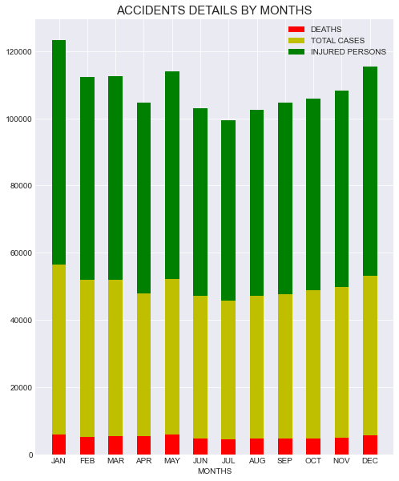

```python
plt.style.use('seaborn-darkgrid')
x=months
y1=deathmonths
y2=casesmonths
y3=injurymonths

plt.figure(figsize=(8,10))
plt.bar(x,y1,label='DEATHS',width=0.5,color='r')
plt.bar(x,y2,label='TOTAL CASES',width=0.5,bottom=y1,color='y')
plt.bar(x,y3,label='INJURED PERSONS',width=0.5,bottom=y2,color='g')
plt.xlabel("MONTHS")
plt.ylabel("")
plt.title("ACCIDENTS DETAILS BY MONTHS",fontsize=15)
plt.legend()
plt.show()
```

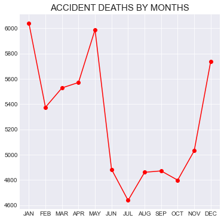

```python
x=months
y1=deathmonths
plt.figure(figsize=(6,6))
plt.plot(x,y1,marker='o',color='red')
plt.title("ACCIDENT DEATHS BY MONTHS",fontsize=15)
plt.show()
```

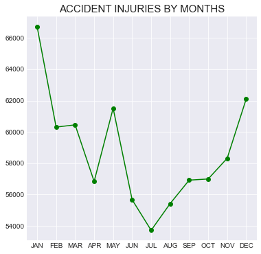

```python
x=months
y3=injurymonths
plt.figure(figsize=(6,6))
plt.plot(x,y3,marker='o',color='g')
plt.title("ACCIDENT INJURIES BY MONTHS",fontsize=15)
plt.show()
```

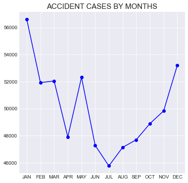

```python
x=months
y2=casesmonths
plt.figure(figsize=(6,6))
plt.plot(x,y2,marker='o',color='b')
plt.title("ACCIDENT CASES BY MONTHS",fontsize=15)
plt.show()
```

## YEARLY DATA

```python
yeardata=mnthdata.resample('Y').sum()
```

### Print index of yearly data set

```python
yeardata.index
```

```
DatetimeIndex(['2005-12-31', '2006-12-31', '2007-12-31', '2008-12-31',
               '2009-12-31', '2010-12-31', '2011-12-31', '2012-12-31',
               '2013-12-31', '2014-12-31', '2015-12-31', '2016-12-31',
               '2017-12-31', '2018-12-31', '2019-12-31', '2020-12-31'],
              dtype='datetime64[ns]', name='DATE', freq='A-DEC')
```

### Print first five records

```python
yeardata.head()
```

| DATE | FATAL | GREVIOUS INJURY CASES | MINOR INJURY CASES | NON INJURY CASES | TOTAL CASES | DEATH | GREVIOUS INJURED PERSON | MINOR INJURED PERSON | TOTAL PERSONS |
| --- | --- | --- | --- | --- | --- | --- | --- | --- | --- |
| 2005-12-31 | 2984 | 23793 | 13579 | 2007 | 42363 | 3203 | 26683 | 22898 | 51124 |
| 2006-12-31 | 3362 | 23752 | 13096 | 1437 | 41647 | 3589 | 26796 | 21536 | 49881 |
| 2007-12-31 | 3465 | 22958 | 11643 | 1851 | 39917 | 3778 | 26326 | 19925 | 48246 |
| 2008-12-31 | 3632 | 22330 | 9859 | 1442 | 37263 | 3901 | 25030 | 17150 | 43857 |
| 2009-12-31 | 3557 | 21608 | 8777 | 1491 | 35433 | 3831 | 24097 | 15819 | 41401 |

### Print columns

```python
yeardata.columns
```

```
Index(['FATAL', 'GREVIOUS INJURY CASES', 'MINOR INJURY CASES',
       'NON INJURY CASES', 'TOTAL CASES', 'DEATH', 'GREVIOUS INJURED PERSON',
       'MINOR INJURED PERSON', 'TOTAL PERSONS'],
      dtype='object')
```

### Drop the columns

```python
yeardata=yeardata.drop(['FATAL','GREVIOUS INJURY CASES','MINOR INJURY CASES','NON INJURY CASES','GREVIOUS INJURED PERSON','MINOR INJURED PERSON'],axis=1)
yeardata
```

| DATE | TOTAL CASES | DEATH | TOTAL PERSONS |
| --- | --- | --- | --- |
| 2005-12-31 | 42363 | 3203 | 51124 |
| 2006-12-31 | 41647 | 3589 | 49881 |
| 2007-12-31 | 39917 | 3778 | 48246 |
| 2008-12-31 | 37263 | 3901 | 43857 |
| 2009-12-31 | 35433 | 3831 | 41401 |
| 2010-12-31 | 35082 | 3950 | 41473 |
| 2011-12-31 | 35216 | 4145 | 41379 |
| 2012-12-31 | 36174 | 4286 | 41915 |
| 2013-12-31 | 35215 | 4258 | 40346 |
| 2014-12-31 | 36282 | 4049 | 41096 |
| 2015-12-31 | 39014 | 4196 | 43735 |
| 2016-12-31 | 39420 | 4287 | 44108 |
| 2017-12-31 | 38470 | 4131 | 42671 |
| 2018-12-31 | 40181 | 4303 | 49761 |
| 2019-12-31 | 41111 | 4440 | 50495 |
| 2020-12-31 | 27877 | 2979 | 33489 |

### Calculate mean

```python
yeardata.mean()
```

```
TOTAL CASES      37541.5625
DEATH             3957.8750
TOTAL PERSONS    44061.0625
dtype: float64
```

## MAXIMUM

```python
yeardata.max()
```

```
TOTAL CASES      42363
DEATH             4440
TOTAL PERSONS    51124
dtype: int64
```

### To show the maximum number of accident cases along with death and injuries in that period

```python
yeardata.sort_values(by='TOTAL CASES',ascending=False).head()
```

| DATE | TOTAL CASES | DEATH | TOTAL PERSONS |
| --- | --- | --- | --- |
| 2005-12-31 | 42363 | 3203 | 51124 |
| 2006-12-31 | 41647 | 3589 | 49881 |
| 2019-12-31 | 41111 | 4440 | 50495 |
| 2018-12-31 | 40181 | 4303 | 49761 |
| 2007-12-31 | 39917 | 3778 | 48246 |

Maximum accident cases occured in the year of 2005

### To show the maximum number of accident injuries along with death and accident cases in that period

```python
yeardata.sort_values(by='TOTAL PERSONS',ascending=False).head()
```

| DATE | TOTAL CASES | DEATH | TOTAL PERSONS |
| --- | --- | --- | --- |
| 2005-12-31 | 42363 | 3203 | 51124 |
| 2019-12-31 | 41111 | 4440 | 50495 |
| 2006-12-31 | 41647 | 3589 | 49881 |
| 2018-12-31 | 40181 | 4303 | 49761 |
| 2007-12-31 | 39917 | 3778 | 48246 |

Maximum accident injuries occured in the year of 2005

### To show the maximum number of accident deaths along with cases and injuries in that period

```python
yeardata.sort_values(by='DEATH',ascending=False).head()
```

| DATE | TOTAL CASES | DEATH | TOTAL PERSONS |
| --- | --- | --- | --- |
| 2019-12-31 | 41111 | 4440 | 50495 |
| 2018-12-31 | 40181 | 4303 | 49761 |
| 2016-12-31 | 39420 | 4287 | 44108 |
| 2012-12-31 | 36174 | 4286 | 41915 |
| 2013-12-31 | 35215 | 4258 | 40346 |

Maximum number of accident deaths occured in the year of 2019

## MINIMUM

```python
yeardata.min()
```

```
TOTAL CASES      27877
DEATH             2979
TOTAL PERSONS    33489
dtype: int64
```

### To show the minimum number of accident cases along with death and injuries in that period

```python
yeardata.sort_values(by='TOTAL CASES').head()
```

| DATE | TOTAL CASES | DEATH | TOTAL PERSONS |
| --- | --- | --- | --- |
| 2020-12-31 | 27877 | 2979 | 33489 |
| 2010-12-31 | 35082 | 3950 | 41473 |
| 2013-12-31 | 35215 | 4258 | 40346 |
| 2011-12-31 | 35216 | 4145 | 41379 |
| 2009-12-31 | 35433 | 3831 | 41401 |

Minimum number of accident cases occured in the year of 2020

### To show the minimum number of accident injuries along with death and total cases in that period

```python
yeardata.sort_values(by='TOTAL PERSONS').head()
```

| DATE | TOTAL CASES | DEATH | TOTAL PERSONS |
| --- | --- | --- | --- |
| 2020-12-31 | 27877 | 2979 | 33489 |
| 2013-12-31 | 35215 | 4258 | 40346 |
| 2014-12-31 | 36282 | 4049 | 41096 |
| 2011-12-31 | 35216 | 4145 | 41379 |
| 2009-12-31 | 35433 | 3831 | 41401 |

Minimum accident injuries occured in the year of 2020

### To show the minimum number of accident deaths along with total cases and injuries in that period

```python
yeardata.sort_values(by='DEATH').head()
```

| DATE | TOTAL CASES | DEATH | TOTAL PERSONS |
| --- | --- | --- | --- |
| 2020-12-31 | 27877 | 2979 | 33489 |
| 2005-12-31 | 42363 | 3203 | 51124 |
| 2006-12-31 | 41647 | 3589 | 49881 |
| 2007-12-31 | 39917 | 3778 | 48246 |
| 2009-12-31 | 35433 | 3831 | 41401 |

Minimum number of accident deaths occured in the year of 2020

# TIMEDATA

### Print first five records

```python
timedata.head()
```

|  | YEAR | REASON | 1AM-3AM | 3AM-6AM | 6AM-9AM | 9AM-12PM | 12PM-15PM | 15PM-18PM | 18PM-21PM | 21PM-24PM | UNKNOWN |
| --- | --- | --- | --- | --- | --- | --- | --- | --- | --- | --- | --- |
| 0 | 2005 | INJURY | 1137 | 1796 | 6106 | 9883 | 8492 | 10530 | 8617 | 3112 | 1451 |
| 1 | 2005 | DEATH | 100 | 174 | 387 | 544 | 483 | 603 | 594 | 247 | 71 |
| 2 | 2005 | CASES | 939 | 1506 | 4957 | 8227 | 6882 | 8419 | 7569 | 2600 | 1264 |
| 3 | 2006 | INJURY | 2379 | 3081 | 5617 | 9094 | 7563 | 9677 | 8355 | 2820 | 1295 |
| 4 | 2006 | DEATH | 228 | 275 | 387 | 551 | 528 | 615 | 605 | 296 | 104 |

### Print columns name

```python
timedata.columns
```

```
Index(['YEAR', 'REASON', '1AM-3AM', '3AM-6AM', '6AM-9AM', '9AM-12PM',
       '12PM-15PM', '15PM-18PM', '18PM-21PM', '21PM-24PM', 'UNKNOWN'],
      dtype='object')
```

### Change column name

```python
timedata.columns=['YEAR', 'CATEGORY', '1AM-3AM', '3AM-6AM', '6AM-9AM', '9AM-12PM',
       '12PM-15PM', '15PM-18PM', '18PM-21PM', '21PM-24PM', 'UNKNOWN']
```

### Group by year and category

```python
timedata1=timedata.groupby(['YEAR','CATEGORY']).sum()
timedata1
```

| YEAR | CATEGORY | 1AM-3AM | 3AM-6AM | 6AM-9AM | 9AM-12PM | 12PM-15PM | 15PM-18PM | 18PM-21PM | 21PM-24PM | UNKNOWN |
| --- | --- | --- | --- | --- | --- | --- | --- | --- | --- | --- |
| 2005 | CASES | 939 | 1506 | 4957 | 8227 | 6882 | 8419 | 7569 | 2600 | 1264 |
|  | DEATH | 100 | 174 | 387 | 544 | 483 | 603 | 594 | 247 | 71 |
|  | INJURY | 1137 | 1796 | 6106 | 9883 | 8492 | 10530 | 8617 | 3112 | 1451 |
| 2006 | CASES | 1989 | 2624 | 4598 | 7544 | 6284 | 7816 | 7188 | 2346 | 1258 |
|  | DEATH | 228 | 275 | 387 | 551 | 528 | 615 | 605 | 296 | 104 |
|  | INJURY | 2379 | 3081 | 5617 | 9094 | 7563 | 9677 | 8355 | 2820 | 1295 |
| 2007 | CASES | 663 | 1020 | 3765 | 8709 | 6278 | 7778 | 7776 | 3132 | 796 |
|  | DEATH | 111 | 168 | 397 | 682 | 535 | 653 | 758 | 420 | 54 |
|  | INJURY | 804 | 1313 | 4615 | 10367 | 7961 | 9669 | 8888 | 3681 | 948 |
| 2008 | CASES | 920 | 1669 | 5456 | 6772 | 6399 | 7637 | 6766 | 1565 | 79 |
|  | DEATH | 172 | 262 | 495 | 596 | 618 | 663 | 805 | 273 | 17 |
|  | INJURY | 1185 | 2003 | 6640 | 7990 | 7718 | 9023 | 7479 | 1730 | 89 |
| 2009 | CASES | 498 | 1205 | 4801 | 6312 | 6422 | 8018 | 6622 | 1499 | 56 |
|  | DEATH | 96 | 243 | 469 | 608 | 663 | 702 | 760 | 270 | 20 |
|  | INJURY | 671 | 1437 | 5792 | 7285 | 7752 | 9521 | 7211 | 1650 | 82 |
| 2010 | CASES | 562 | 1204 | 4913 | 6132 | 6440 | 7966 | 6351 | 1454 | 60 |
|  | DEATH | 145 | 244 | 487 | 567 | 657 | 771 | 801 | 261 | 17 |
|  | INJURY | 746 | 1415 | 5987 | 7161 | 7789 | 9545 | 7027 | 1686 | 117 |
| 2011 | CASES | 495 | 1265 | 5051 | 6119 | 6393 | 8071 | 6335 | 1387 | 100 |
|  | DEATH | 113 | 264 | 521 | 600 | 696 | 800 | 840 | 281 | 30 |
|  | INJURY | 540 | 1475 | 6295 | 7143 | 7631 | 9648 | 6877 | 1624 | 146 |
| 2012 | CASES | 394 | 785 | 3720 | 6795 | 6091 | 8075 | 7359 | 2766 | 189 |
|  | DEATH | 88 | 170 | 492 | 628 | 655 | 903 | 848 | 482 | 20 |
|  | INJURY | 591 | 984 | 4504 | 7797 | 7007 | 9540 | 8050 | 3148 | 294 |
| 2013 | CASES | 537 | 1341 | 5378 | 6329 | 6210 | 7706 | 6207 | 1424 | 83 |
|  | DEATH | 109 | 252 | 566 | 685 | 679 | 766 | 879 | 300 | 22 |
|  | INJURY | 668 | 1596 | 6216 | 7308 | 7308 | 8913 | 6663 | 1578 | 96 |
| 2014 | CASES | 574 | 1422 | 5839 | 6712 | 6363 | 7915 | 6025 | 1327 | 105 |
|  | DEATH | 111 | 246 | 582 | 613 | 641 | 754 | 806 | 269 | 27 |
|  | INJURY | 752 | 1596 | 6798 | 7552 | 7477 | 8885 | 6411 | 1497 | 128 |
| 2015 | CASES | 692 | 1615 | 6240 | 7187 | 6656 | 8465 | 6500 | 1544 | 115 |
|  | DEATH | 163 | 245 | 597 | 642 | 626 | 752 | 815 | 317 | 39 |
|  | INJURY | 805 | 1818 | 7048 | 8161 | 7588 | 9602 | 6963 | 1648 | 102 |
| 2016 | CASES | 679 | 1736 | 6277 | 6987 | 6632 | 8440 | 6904 | 1608 | 157 |
|  | DEATH | 171 | 275 | 605 | 613 | 645 | 736 | 884 | 309 | 49 |
|  | INJURY | 863 | 1937 | 7098 | 7782 | 7659 | 9391 | 7418 | 1784 | 176 |
| 2017 | CASES | 690 | 1730 | 6165 | 6871 | 6211 | 8056 | 6751 | 1789 | 207 |
|  | DEATH | 146 | 275 | 548 | 601 | 591 | 697 | 876 | 350 | 47 |
|  | INJURY | 866 | 1884 | 6744 | 7536 | 7169 | 9041 | 7246 | 1951 | 234 |
| 2018 | CASES | 914 | 1075 | 4674 | 7396 | 6182 | 8011 | 8382 | 3485 | 62 |
|  | DEATH | 215 | 223 | 514 | 621 | 548 | 698 | 901 | 574 | 9 |
|  | INJURY | 1043 | 1287 | 5195 | 8235 | 7183 | 9507 | 9083 | 3872 | 53 |
| 2019 | CASES | 901 | 1143 | 4904 | 7705 | 6380 | 8106 | 8465 | 3438 | 69 |
|  | DEATH | 205 | 221 | 540 | 579 | 626 | 748 | 890 | 620 | 11 |
|  | INJURY | 997 | 1250 | 5524 | 8663 | 7251 | 9415 | 9187 | 3706 | 62 |
| 2020 | CASES | 549 | 707 | 3299 | 5237 | 4409 | 5667 | 6028 | 1938 | 43 |
|  | DEATH | 161 | 135 | 346 | 422 | 382 | 517 | 645 | 364 | 7 |
|  | INJURY | 424 | 590 | 2882 | 4680 | 3883 | 5044 | 5195 | 1688 | 30 |

### Print index of data set

```python
timedata1.index
```

```
MultiIndex([(2005,  'CASES'),
            (2005,  'DEATH'),
            (2005, 'INJURY'),
            (2006,  'CASES'),
            (2006,  'DEATH'),
            (2006, 'INJURY'),
            (2007,  'CASES'),
            (2007,  'DEATH'),
            (2007, 'INJURY'),
            (2008,  'CASES'),
            (2008,  'DEATH'),
            (2008, 'INJURY'),
            (2009,  'CASES'),
            (2009,  'DEATH'),
            (2009, 'INJURY'),
            (2010,  'CASES'),
            (2010,  'DEATH'),
            (2010, 'INJURY'),
            (2011,  'CASES'),
            (2011,  'DEATH'),
            (2011, 'INJURY'),
            (2012,  'CASES'),
            (2012,  'DEATH'),
            (2012, 'INJURY'),
            (2013,  'CASES'),
            (2013,  'DEATH'),
            (2013, 'INJURY'),
            (2014,  'CASES'),
            (2014,  'DEATH'),
            (2014, 'INJURY'),
            (2015,  'CASES'),
            (2015,  'DEATH'),
            (2015, 'INJURY'),
            (2016,  'CASES'),
            (2016,  'DEATH'),
            (2016, 'INJURY'),
            (2017,  'CASES'),
            (2017,  'DEATH'),
            (2017, 'INJURY'),
            (2018,  'CASES'),
            (2018,  'DEATH'),
            (2018, 'INJURY'),
            (2019,  'CASES'),
            (2019,  'DEATH'),
            (2019, 'INJURY'),
            (2020,  'CASES'),
            (2020,  'DEATH'),
            (2020, 'INJURY')],
           names=['YEAR', 'CATEGORY'])
```

### To check is there any missing value

```python
timedata1.isnull().sum()
```

```
1AM-3AM      0
3AM-6AM      0
6AM-9AM      0
9AM-12PM     0
12PM-15PM    0
15PM-18PM    0
18PM-21PM    0
21PM-24PM    0
UNKNOWN      0
dtype: int64
```

### Print Statistical information

```python
timedata1.describe()
```

|  | 1AM-3AM | 3AM-6AM | 6AM-9AM | 9AM-12PM | 12PM-15PM | 15PM-18PM | 18PM-21PM | 21PM-24PM | UNKNOWN |
| --- | --- | --- | --- | --- | --- | --- | --- | --- | --- |
| count | 48.000000 | 48.000000 | 48.000000 | 48.000000 | 48.000000 | 48.00000 | 48.000000 | 48.000000 | 48.000000 |
| mean | 600.020833 | 1066.270833 | 3771.479167 | 5150.479167 | 4734.083333 | 5926.56250 | 5095.937500 | 1585.625000 | 218.541667 |
| std | 466.451315 | 725.331699 | 2498.234193 | 3393.038167 | 3055.500216 | 3840.47764 | 3175.230716 | 1110.291214 | 376.555325 |
| min | 88.000000 | 135.000000 | 346.000000 | 422.000000 | 382.000000 | 517.00000 | 594.000000 | 247.000000 | 7.000000 |
| 25% | 171.750000 | 263.500000 | 561.500000 | 626.250000 | 656.500000 | 763.00000 | 878.250000 | 406.000000 | 42.000000 |
| 50% | 568.000000 | 1204.500000 | 4737.500000 | 6783.500000 | 6323.500000 | 7988.50000 | 6561.000000 | 1571.500000 | 80.500000 |
| 75% | 819.500000 | 1596.000000 | 5876.000000 | 7590.250000 | 7200.000000 | 9027.50000 | 7373.750000 | 2049.750000 | 148.750000 |
| max | 2379.000000 | 3081.000000 | 7098.000000 | 10367.000000 | 8492.000000 | 10530.00000 | 9187.000000 | 3872.000000 | 1451.000000 |

### Print data information

```python
timedata1.info()
```

```
<class 'pandas.core.frame.DataFrame'>
MultiIndex: 48 entries, (2005, 'CASES') to (2020, 'INJURY')
Data columns (total 9 columns):
 #   Column     Non-Null Count  Dtype
---  ------     --------------  -----
 0   1AM-3AM    48 non-null     int64
 1   3AM-6AM    48 non-null     int64
 2   6AM-9AM    48 non-null     int64
 3   9AM-12PM   48 non-null     int64
 4   12PM-15PM  48 non-null     int64
 5   15PM-18PM  48 non-null     int64
 6   18PM-21PM  48 non-null     int64
 7   21PM-24PM  48 non-null     int64
 8   UNKNOWN    48 non-null     int64
dtypes: int64(9)
memory usage: 3.7+ KB
```

### Calculate correlation

```python
timedata1.corr()
```

|  | 1AM-3AM | 3AM-6AM | 6AM-9AM | 9AM-12PM | 12PM-15PM | 15PM-18PM | 18PM-21PM | 21PM-24PM | UNKNOWN |
| --- | --- | --- | --- | --- | --- | --- | --- | --- | --- |
| 1AM-3AM | 1.000000 | 0.904889 | 0.691890 | 0.770487 | 0.729920 | 0.728696 | 0.756078 | 0.696724 | 0.673349 |
| 3AM-6AM | 0.904889 | 1.000000 | 0.891232 | 0.858956 | 0.871539 | 0.863627 | 0.822677 | 0.612117 | 0.549509 |
| 6AM-9AM | 0.691890 | 0.891232 | 1.000000 | 0.928882 | 0.969917 | 0.964923 | 0.911340 | 0.669966 | 0.293845 |
| 9AM-12PM | 0.770487 | 0.858956 | 0.928882 | 1.000000 | 0.982315 | 0.983233 | 0.987337 | 0.871659 | 0.503511 |
| 12PM-15PM | 0.729920 | 0.871539 | 0.969917 | 0.982315 | 1.000000 | 0.998070 | 0.970885 | 0.792284 | 0.408040 |
| 15PM-18PM | 0.728696 | 0.863627 | 0.964923 | 0.983233 | 0.998070 | 1.000000 | 0.977435 | 0.810802 | 0.402276 |
| 18PM-21PM | 0.756078 | 0.822677 | 0.911340 | 0.987337 | 0.970885 | 0.977435 | 1.000000 | 0.903813 | 0.433861 |
| 21PM-24PM | 0.696724 | 0.612117 | 0.669966 | 0.871659 | 0.792284 | 0.810802 | 0.903813 | 1.000000 | 0.503699 |
| UNKNOWN | 0.673349 | 0.549509 | 0.293845 | 0.503511 | 0.408040 | 0.402276 | 0.433861 | 0.503699 | 1.000000 |

### Group by category and year

```python
timedata2=timedata.groupby(['CATEGORY','YEAR']).sum()
timedata2
```

| CATEGORY | YEAR | 1AM-3AM | 3AM-6AM | 6AM-9AM | 9AM-12PM | 12PM-15PM | 15PM-18PM | 18PM-21PM | 21PM-24PM | UNKNOWN |
| --- | --- | --- | --- | --- | --- | --- | --- | --- | --- | --- |
| CASES | 2005 | 939 | 1506 | 4957 | 8227 | 6882 | 8419 | 7569 | 2600 | 1264 |
|  | 2006 | 1989 | 2624 | 4598 | 7544 | 6284 | 7816 | 7188 | 2346 | 1258 |
|  | 2007 | 663 | 1020 | 3765 | 8709 | 6278 | 7778 | 7776 | 3132 | 796 |
|  | 2008 | 920 | 1669 | 5456 | 6772 | 6399 | 7637 | 6766 | 1565 | 79 |
|  | 2009 | 498 | 1205 | 4801 | 6312 | 6422 | 8018 | 6622 | 1499 | 56 |
|  | 2010 | 562 | 1204 | 4913 | 6132 | 6440 | 7966 | 6351 | 1454 | 60 |
|  | 2011 | 495 | 1265 | 5051 | 6119 | 6393 | 8071 | 6335 | 1387 | 100 |
|  | 2012 | 394 | 785 | 3720 | 6795 | 6091 | 8075 | 7359 | 2766 | 189 |
|  | 2013 | 537 | 1341 | 5378 | 6329 | 6210 | 7706 | 6207 | 1424 | 83 |
|  | 2014 | 574 | 1422 | 5839 | 6712 | 6363 | 7915 | 6025 | 1327 | 105 |
|  | 2015 | 692 | 1615 | 6240 | 7187 | 6656 | 8465 | 6500 | 1544 | 115 |
|  | 2016 | 679 | 1736 | 6277 | 6987 | 6632 | 8440 | 6904 | 1608 | 157 |
|  | 2017 | 690 | 1730 | 6165 | 6871 | 6211 | 8056 | 6751 | 1789 | 207 |
|  | 2018 | 914 | 1075 | 4674 | 7396 | 6182 | 8011 | 8382 | 3485 | 62 |
|  | 2019 | 901 | 1143 | 4904 | 7705 | 6380 | 8106 | 8465 | 3438 | 69 |
|  | 2020 | 549 | 707 | 3299 | 5237 | 4409 | 5667 | 6028 | 1938 | 43 |
| DEATH | 2005 | 100 | 174 | 387 | 544 | 483 | 603 | 594 | 247 | 71 |
|  | 2006 | 228 | 275 | 387 | 551 | 528 | 615 | 605 | 296 | 104 |
|  | 2007 | 111 | 168 | 397 | 682 | 535 | 653 | 758 | 420 | 54 |
|  | 2008 | 172 | 262 | 495 | 596 | 618 | 663 | 805 | 273 | 17 |
|  | 2009 | 96 | 243 | 469 | 608 | 663 | 702 | 760 | 270 | 20 |
|  | 2010 | 145 | 244 | 487 | 567 | 657 | 771 | 801 | 261 | 17 |
|  | 2011 | 113 | 264 | 521 | 600 | 696 | 800 | 840 | 281 | 30 |
|  | 2012 | 88 | 170 | 492 | 628 | 655 | 903 | 848 | 482 | 20 |
|  | 2013 | 109 | 252 | 566 | 685 | 679 | 766 | 879 | 300 | 22 |
|  | 2014 | 111 | 246 | 582 | 613 | 641 | 754 | 806 | 269 | 27 |
|  | 2015 | 163 | 245 | 597 | 642 | 626 | 752 | 815 | 317 | 39 |
|  | 2016 | 171 | 275 | 605 | 613 | 645 | 736 | 884 | 309 | 49 |
|  | 2017 | 146 | 275 | 548 | 601 | 591 | 697 | 876 | 350 | 47 |
|  | 2018 | 215 | 223 | 514 | 621 | 548 | 698 | 901 | 574 | 9 |
|  | 2019 | 205 | 221 | 540 | 579 | 626 | 748 | 890 | 620 | 11 |
|  | 2020 | 161 | 135 | 346 | 422 | 382 | 517 | 645 | 364 | 7 |
| INJURY | 2005 | 1137 | 1796 | 6106 | 9883 | 8492 | 10530 | 8617 | 3112 | 1451 |
|  | 2006 | 2379 | 3081 | 5617 | 9094 | 7563 | 9677 | 8355 | 2820 | 1295 |
|  | 2007 | 804 | 1313 | 4615 | 10367 | 7961 | 9669 | 8888 | 3681 | 948 |
|  | 2008 | 1185 | 2003 | 6640 | 7990 | 7718 | 9023 | 7479 | 1730 | 89 |
|  | 2009 | 671 | 1437 | 5792 | 7285 | 7752 | 9521 | 7211 | 1650 | 82 |
|  | 2010 | 746 | 1415 | 5987 | 7161 | 7789 | 9545 | 7027 | 1686 | 117 |
|  | 2011 | 540 | 1475 | 6295 | 7143 | 7631 | 9648 | 6877 | 1624 | 146 |
|  | 2012 | 591 | 984 | 4504 | 7797 | 7007 | 9540 | 8050 | 3148 | 294 |
|  | 2013 | 668 | 1596 | 6216 | 7308 | 7308 | 8913 | 6663 | 1578 | 96 |
|  | 2014 | 752 | 1596 | 6798 | 7552 | 7477 | 8885 | 6411 | 1497 | 128 |
|  | 2015 | 805 | 1818 | 7048 | 8161 | 7588 | 9602 | 6963 | 1648 | 102 |
|  | 2016 | 863 | 1937 | 7098 | 7782 | 7659 | 9391 | 7418 | 1784 | 176 |
|  | 2017 | 866 | 1884 | 6744 | 7536 | 7169 | 9041 | 7246 | 1951 | 234 |
|  | 2018 | 1043 | 1287 | 5195 | 8235 | 7183 | 9507 | 9083 | 3872 | 53 |
|  | 2019 | 997 | 1250 | 5524 | 8663 | 7251 | 9415 | 9187 | 3706 | 62 |
|  | 2020 | 424 | 590 | 2882 | 4680 | 3883 | 5044 | 5195 | 1688 | 30 |

### Extract case details from the data set

```python
casetime=timedata2.loc['CASES']
casetime
```

| YEAR | 1AM-3AM | 3AM-6AM | 6AM-9AM | 9AM-12PM | 12PM-15PM | 15PM-18PM | 18PM-21PM | 21PM-24PM | UNKNOWN |
| --- | --- | --- | --- | --- | --- | --- | --- | --- | --- |
| 2005 | 939 | 1506 | 4957 | 8227 | 6882 | 8419 | 7569 | 2600 | 1264 |
| 2006 | 1989 | 2624 | 4598 | 7544 | 6284 | 7816 | 7188 | 2346 | 1258 |
| 2007 | 663 | 1020 | 3765 | 8709 | 6278 | 7778 | 7776 | 3132 | 796 |
| 2008 | 920 | 1669 | 5456 | 6772 | 6399 | 7637 | 6766 | 1565 | 79 |
| 2009 | 498 | 1205 | 4801 | 6312 | 6422 | 8018 | 6622 | 1499 | 56 |
| 2010 | 562 | 1204 | 4913 | 6132 | 6440 | 7966 | 6351 | 1454 | 60 |
| 2011 | 495 | 1265 | 5051 | 6119 | 6393 | 8071 | 6335 | 1387 | 100 |
| 2012 | 394 | 785 | 3720 | 6795 | 6091 | 8075 | 7359 | 2766 | 189 |
| 2013 | 537 | 1341 | 5378 | 6329 | 6210 | 7706 | 6207 | 1424 | 83 |
| 2014 | 574 | 1422 | 5839 | 6712 | 6363 | 7915 | 6025 | 1327 | 105 |
| 2015 | 692 | 1615 | 6240 | 7187 | 6656 | 8465 | 6500 | 1544 | 115 |
| 2016 | 679 | 1736 | 6277 | 6987 | 6632 | 8440 | 6904 | 1608 | 157 |
| 2017 | 690 | 1730 | 6165 | 6871 | 6211 | 8056 | 6751 | 1789 | 207 |
| 2018 | 914 | 1075 | 4674 | 7396 | 6182 | 8011 | 8382 | 3485 | 62 |
| 2019 | 901 | 1143 | 4904 | 7705 | 6380 | 8106 | 8465 | 3438 | 69 |
| 2020 | 549 | 707 | 3299 | 5237 | 4409 | 5667 | 6028 | 1938 | 43 |

### Extract death details from data set

```python
deathtime=timedata2.loc['DEATH']
deathtime
```

| YEAR | 1AM-3AM | 3AM-6AM | 6AM-9AM | 9AM-12PM | 12PM-15PM | 15PM-18PM | 18PM-21PM | 21PM-24PM | UNKNOWN |
| --- | --- | --- | --- | --- | --- | --- | --- | --- | --- |
| 2005 | 100 | 174 | 387 | 544 | 483 | 603 | 594 | 247 | 71 |
| 2006 | 228 | 275 | 387 | 551 | 528 | 615 | 605 | 296 | 104 |
| 2007 | 111 | 168 | 397 | 682 | 535 | 653 | 758 | 420 | 54 |
| 2008 | 172 | 262 | 495 | 596 | 618 | 663 | 805 | 273 | 17 |
| 2009 | 96 | 243 | 469 | 608 | 663 | 702 | 760 | 270 | 20 |
| 2010 | 145 | 244 | 487 | 567 | 657 | 771 | 801 | 261 | 17 |
| 2011 | 113 | 264 | 521 | 600 | 696 | 800 | 840 | 281 | 30 |
| 2012 | 88 | 170 | 492 | 628 | 655 | 903 | 848 | 482 | 20 |
| 2013 | 109 | 252 | 566 | 685 | 679 | 766 | 879 | 300 | 22 |
| 2014 | 111 | 246 | 582 | 613 | 641 | 754 | 806 | 269 | 27 |
| 2015 | 163 | 245 | 597 | 642 | 626 | 752 | 815 | 317 | 39 |
| 2016 | 171 | 275 | 605 | 613 | 645 | 736 | 884 | 309 | 49 |
| 2017 | 146 | 275 | 548 | 601 | 591 | 697 | 876 | 350 | 47 |
| 2018 | 215 | 223 | 514 | 621 | 548 | 698 | 901 | 574 | 9 |
| 2019 | 205 | 221 | 540 | 579 | 626 | 748 | 890 | 620 | 11 |
| 2020 | 161 | 135 | 346 | 422 | 382 | 517 | 645 | 364 | 7 |

### Extract injury details from data set

```python
injurytime=timedata2.loc['INJURY']
injurytime
```

| YEAR | 1AM-3AM | 3AM-6AM | 6AM-9AM | 9AM-12PM | 12PM-15PM | 15PM-18PM | 18PM-21PM | 21PM-24PM | UNKNOWN |
| --- | --- | --- | --- | --- | --- | --- | --- | --- | --- |
| 2005 | 1137 | 1796 | 6106 | 9883 | 8492 | 10530 | 8617 | 3112 | 1451 |
| 2006 | 2379 | 3081 | 5617 | 9094 | 7563 | 9677 | 8355 | 2820 | 1295 |
| 2007 | 804 | 1313 | 4615 | 10367 | 7961 | 9669 | 8888 | 3681 | 948 |
| 2008 | 1185 | 2003 | 6640 | 7990 | 7718 | 9023 | 7479 | 1730 | 89 |
| 2009 | 671 | 1437 | 5792 | 7285 | 7752 | 9521 | 7211 | 1650 | 82 |
| 2010 | 746 | 1415 | 5987 | 7161 | 7789 | 9545 | 7027 | 1686 | 117 |
| 2011 | 540 | 1475 | 6295 | 7143 | 7631 | 9648 | 6877 | 1624 | 146 |
| 2012 | 591 | 984 | 4504 | 7797 | 7007 | 9540 | 8050 | 3148 | 294 |
| 2013 | 668 | 1596 | 6216 | 7308 | 7308 | 8913 | 6663 | 1578 | 96 |
| 2014 | 752 | 1596 | 6798 | 7552 | 7477 | 8885 | 6411 | 1497 | 128 |
| 2015 | 805 | 1818 | 7048 | 8161 | 7588 | 9602 | 6963 | 1648 | 102 |
| 2016 | 863 | 1937 | 7098 | 7782 | 7659 | 9391 | 7418 | 1784 | 176 |
| 2017 | 866 | 1884 | 6744 | 7536 | 7169 | 9041 | 7246 | 1951 | 234 |
| 2018 | 1043 | 1287 | 5195 | 8235 | 7183 | 9507 | 9083 | 3872 | 53 |
| 2019 | 997 | 1250 | 5524 | 8663 | 7251 | 9415 | 9187 | 3706 | 62 |
| 2020 | 424 | 590 | 2882 | 4680 | 3883 | 5044 | 5195 | 1688 | 30 |

### Calculate mean of total cases

```python
casetime.mean()
```

```
1AM-3AM       749.7500
3AM-6AM      1377.9375
6AM-9AM      5002.3125
9AM-12PM     6939.6250
12PM-15PM    6264.5000
15PM-18PM    7884.1250
18PM-21PM    6951.7500
21PM-24PM    2081.3750
UNKNOWN       290.1875
dtype: float64
```

### Calculate mean of injuries

```python
injurytime.mean()
```

```
1AM-3AM       904.4375
3AM-6AM      1591.3750
6AM-9AM      5816.3125
9AM-12PM     7914.8125
12PM-15PM    7339.4375
15PM-18PM    9184.4375
18PM-21PM    7541.8750
21PM-24PM    2323.4375
UNKNOWN       331.4375
dtype: float64
```

### Calculate mean of accident deaths

```python
deathtime.mean()
```

```
1AM-3AM      145.8750
3AM-6AM      229.5000
6AM-9AM      495.8125
9AM-12PM     597.0000
12PM-15PM    598.3125
15PM-18PM    711.1250
18PM-21PM    794.1875
21PM-24PM    352.0625
UNKNOWN       34.0000
dtype: float64
```

## MAXIMUM

### To show the maximum of total cases among all the time intervals

```python
tcasetime=casetime.sum()
tcasetime.sort_values(ascending=False)
```

```
15PM-18PM    126146
18PM-21PM    111228
9AM-12PM     111034
12PM-15PM    100232
6AM-9AM       80037
21PM-24PM     33302
3AM-6AM       22047
1AM-3AM       11996
UNKNOWN        4643
dtype: int64
```

Maximum number of accident cases occured in the time interval of 3.00PM to 6.00PM.

### To show the maximum of total injuries among all the time intervals

```python
tinjurytime=injurytime.sum()
tinjurytime.sort_values(ascending=False)
```

```
15PM-18PM    146951
9AM-12PM     126637
18PM-21PM    120670
12PM-15PM    117431
6AM-9AM       93061
21PM-24PM     37175
3AM-6AM       25462
1AM-3AM       14471
UNKNOWN        5303
dtype: int64
```

Maximum number of accident injuries occured in the time in time interval of 3.00PM to 6.00PM.

### To show the maximum of total deaths among all the time intervals

```python
tdeathtime=deathtime.sum()
tdeathtime.sort_values(ascending=False)
```

```
18PM-21PM    12707
15PM-18PM    11378
12PM-15PM     9573
9AM-12PM      9552
6AM-9AM       7933
21PM-24PM     5633
3AM-6AM       3672
1AM-3AM       2334
UNKNOWN        544
dtype: int64
```

Maximum number of accident deaths occured in the time interval of 6.00PM to 9.00PM

## MINIMUM

### To show the minimum of total cases among all the time intervals

```python
tcasetime=casetime.sum()
tcasetime.sort_values(ascending=True)
```

```
UNKNOWN        4643
1AM-3AM       11996
3AM-6AM       22047
21PM-24PM     33302
6AM-9AM       80037
12PM-15PM    100232
9AM-12PM     111034
18PM-21PM    111228
15PM-18PM    126146
dtype: int64
```

Minimum number of accident cases occured in time interval of unknown times

### To show the minimum of total injuries among all the time intervals

```python
tinjurytime=injurytime.sum()
tinjurytime.sort_values(ascending=True)
```

```
UNKNOWN        5303
1AM-3AM       14471
3AM-6AM       25462
21PM-24PM     37175
6AM-9AM       93061
12PM-15PM    117431
18PM-21PM    120670
9AM-12PM     126637
15PM-18PM    146951
dtype: int64
```

Minimum number of accident cases occured in unknown time intervals

### To show the minimum of total deaths among all the time intervals

```python
tdeathtime=deathtime.sum()
tdeathtime.sort_values(ascending=True)
```

```
UNKNOWN        544
1AM-3AM       2334
3AM-6AM       3672
21PM-24PM     5633
6AM-9AM       7933
9AM-12PM      9552
12PM-15PM     9573
15PM-18PM    11378
18PM-21PM    12707
dtype: int64
```

Minimum number of accident deaths occured in unknown time intervals

## DATA VISUALIZATION

```python
x=['1AM-3AM', '3AM-6AM', '6AM-9AM', '9AM-12PM', '12PM-15PM', '15PM-18PM',
       '18PM-21PM', '21PM-24PM', 'UNKNOWN']
y1=tcasetime
y2=tinjurytime
y3=tdeathtime
```

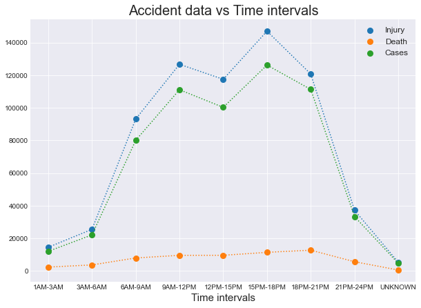

```python
plt.figure(figsize=(10,7))
plt.scatter(x,y2,label='Injury',linewidth=3)
plt.scatter(x,y3,label='Death',linewidth=3)
plt.scatter(x,y1,label='Cases',linewidth=3)
plt.plot(x,y2,':')
plt.plot(x,y3,':')
plt.plot(x,y1,':')
plt.title("Accident data vs Time intervals",fontsize=20)
plt.xlabel("Time intervals",fontsize=15)
plt.legend(loc='upper right',fontsize=12)
plt.show()
```

# TYPES OF ROAD DATA

## To print top 5 records

```python
roaddata.head()
```

|  | YEAR | ROADS | CASES | PERSONS KILLED | PERSONS INJURED |
| --- | --- | --- | --- | --- | --- |
| 0 | 2005 | NH | 11034 | 1251 | 13391 |
| 1 | 2005 | SH | 5335 | 470 | 6860 |
| 2 | 2005 | OTHERS | 25994 | 1482 | 30873 |
| 3 | 2006 | NH | 10664 | 1309 | 12999 |
| 4 | 2006 | SH | 5215 | 489 | 6610 |

### To print column names

```python
roaddata.columns
```

```
Index(['YEAR', 'ROADS', 'CASES', 'PERSONS KILLED', 'PERSONS INJURED'], dtype='object')
```

### To check is there any missing values in data set

```python
roaddata.isnull().sum()
```

```
YEAR               0
ROADS              0
CASES              0
PERSONS KILLED     0
PERSONS INJURED    0
dtype: int64
```

### Print statistical informations of data

```python
roaddata.describe()
```

|  | YEAR | CASES | PERSONS KILLED | PERSONS INJURED |
| --- | --- | --- | --- | --- |
| count | 48.000000 | 48.000000 | 48.000000 | 48.00000 |
| mean | 2012.500000 | 12674.562500 | 1319.291667 | 14442.81250 |
| std | 4.658554 | 6971.344938 | 481.894884 | 7662.19574 |
| min | 2005.000000 | 5215.000000 | 470.000000 | 6519.00000 |
| 25% | 2008.750000 | 6845.500000 | 869.250000 | 7992.75000 |
| 50% | 2012.500000 | 9400.000000 | 1322.500000 | 10791.50000 |
| 75% | 2016.250000 | 19803.500000 | 1694.250000 | 22361.50000 |
| max | 2020.000000 | 25994.000000 | 2245.000000 | 30873.00000 |

### Print informations of data

```python
roaddata.info()
```

```
<class 'pandas.core.frame.DataFrame'>
RangeIndex: 48 entries, 0 to 47
Data columns (total 5 columns):
 #   Column           Non-Null Count  Dtype
---  ------           --------------  -----
 0   YEAR             48 non-null     int64
 1   ROADS            48 non-null     object
 2   CASES            48 non-null     int64
 3   PERSONS KILLED   48 non-null     int64
 4   PERSONS INJURED  48 non-null     int64
dtypes: int64(4), object(1)
memory usage: 2.0+ KB
```

### Print unique roads in accident dataset

```python
roaddata['ROADS'].unique()
```

```
array(['NH', 'SH', 'OTHERS'], dtype=object)
```

### To group by road and years

```python
roaddata1=roaddata.groupby(['ROADS','YEAR']).sum()
roaddata1.head()
```

| ROADS | YEAR | CASES | PERSONS KILLED | PERSONS INJURED |
| --- | --- | --- | --- | --- |
| NH | 2005 | 11034 | 1251 | 13391 |
|  | 2006 | 10664 | 1309 | 12999 |
|  | 2007 | 10907 | 1397 | 13369 |
|  | 2008 | 9997 | 1403 | 11833 |
|  | 2009 | 9425 | 1373 | 11152 |

### Print indexes of data

```python
roaddata1.index
```

```
MultiIndex([(    'NH', 2005),
            (    'NH', 2006),
            (    'NH', 2007),
            (    'NH', 2008),
            (    'NH', 2009),
            (    'NH', 2010),
            (    'NH', 2011),
            (    'NH', 2012),
            (    'NH', 2013),
            (    'NH', 2014),
            (    'NH', 2015),
            (    'NH', 2016),
            (    'NH', 2017),
            (    'NH', 2018),
            (    'NH', 2019),
            (    'NH', 2020),
            ('OTHERS', 2005),
            ('OTHERS', 2006),
            ('OTHERS', 2007),
            ('OTHERS', 2008),
            ('OTHERS', 2009),
            ('OTHERS', 2010),
            ('OTHERS', 2011),
            ('OTHERS', 2012),
            ('OTHERS', 2013),
            ('OTHERS', 2014),
            ('OTHERS', 2015),
            ('OTHERS', 2016),
            ('OTHERS', 2017),
            ('OTHERS', 2018),
            ('OTHERS', 2019),
            ('OTHERS', 2020),
            (    'SH', 2005),
            (    'SH', 2006),
            (    'SH', 2007),
            (    'SH', 2008),
            (    'SH', 2009),
            (    'SH', 2010),
            (    'SH', 2011),
            (    'SH', 2012),
            (    'SH', 2013),
            (    'SH', 2014),
            (    'SH', 2015),
            (    'SH', 2016),
            (    'SH', 2017),
            (    'SH', 2018),
            (    'SH', 2019),
            (    'SH', 2020)],
           names=['ROADS', 'YEAR'])
```

### Extract National highway informations from data set

```python
roadnh=roaddata1.loc['NH']
roadnh
```

| YEAR | CASES | PERSONS KILLED | PERSONS INJURED |
| --- | --- | --- | --- |
| 2005 | 11034 | 1251 | 13391 |
| 2006 | 10664 | 1309 | 12999 |
| 2007 | 10907 | 1397 | 13369 |
| 2008 | 9997 | 1403 | 11833 |
| 2009 | 9425 | 1373 | 11152 |
| 2010 | 9473 | 1375 | 11041 |
| 2011 | 9519 | 1432 | 11201 |
| 2012 | 9375 | 1444 | 11094 |
| 2013 | 8911 | 1336 | 10093 |
| 2014 | 9006 | 1261 | 10282 |
| 2015 | 9442 | 1368 | 10542 |
| 2016 | 9209 | 1263 | 10521 |
| 2017 | 8993 | 1309 | 9990 |
| 2018 | 9161 | 1248 | 10461 |
| 2019 | 8097 | 979 | 9335 |
| 2020 | 5876 | 629 | 6519 |

```python
roadsh=roaddata1.loc['SH']
roadsh
```

| YEAR | CASES | PERSONS KILLED | PERSONS INJURED |
| --- | --- | --- | --- |
| 2005 | 5335 | 470 | 6860 |
| 2006 | 5215 | 489 | 6610 |
| 2007 | 6258 | 717 | 8186 |
| 2008 | 6452 | 767 | 7874 |
| 2009 | 6637 | 775 | 7942 |
| 2010 | 6539 | 847 | 8124 |
| 2011 | 6401 | 836 | 7794 |
| 2012 | 6593 | 885 | 7899 |
| 2013 | 6140 | 774 | 7097 |
| 2014 | 6888 | 841 | 7835 |
| 2015 | 6718 | 919 | 7965 |
| 2016 | 7135 | 885 | 8002 |
| 2017 | 7043 | 837 | 7913 |
| 2018 | 7552 | 876 | 8756 |
| 2019 | 9001 | 1216 | 10202 |
| 2020 | 6247 | 849 | 6972 |

### Extract informations other than NH and SH from data set

```python
roadothers=roaddata1.loc['OTHERS']
roadothers
```

| YEAR | CASES | PERSONS KILLED | PERSONS INJURED |
| --- | --- | --- | --- |
| 2005 | 25994 | 1482 | 30873 |
| 2006 | 25768 | 1791 | 30272 |
| 2007 | 22752 | 1664 | 26691 |
| 2008 | 20814 | 1731 | 24150 |
| 2009 | 19371 | 1683 | 22307 |
| 2010 | 19070 | 1728 | 22308 |
| 2011 | 19296 | 1877 | 22384 |
| 2012 | 20081 | 1923 | 22856 |
| 2013 | 19711 | 2037 | 22354 |
| 2014 | 21136 | 2014 | 23717 |
| 2015 | 22684 | 1987 | 25358 |
| 2016 | 23076 | 2139 | 25585 |
| 2017 | 22434 | 1985 | 24768 |
| 2018 | 23468 | 2179 | 26241 |
| 2019 | 24013 | 2245 | 26518 |
| 2020 | 23468 | 1501 | 17019 |

### Calculate mean of National highway data

```python
roadnh.mean()
```

```
CASES               9318.0625
PERSONS KILLED      1273.5625
PERSONS INJURED    10863.9375
dtype: float64
```

### Calculate mean of State highway data

```python
roadsh.mean()
```

```
CASES              6634.6250
PERSONS KILLED      811.4375
PERSONS INJURED    7876.9375
dtype: float64
```

### Calculate mean of Others data

```python
roadothers.mean()
```

```
CASES              22071.0000
PERSONS KILLED      1872.8750
PERSONS INJURED    24587.5625
dtype: float64
```

### To create pivot table

```python
rd=roaddata.pivot_table(index='YEAR',columns='ROADS')
rd
```

| ROADS YEAR | CASES NH | CASES OTHERS | CASES SH | PERSONS INJURED NH | PERSONS INJURED OTHERS | PERSONS INJURED SH | PERSONS KILLED NH | PERSONS KILLED OTHERS | PERSONS KILLED SH |
| --- | --- | --- | --- | --- | --- | --- | --- | --- | --- |
| 2005 | 11034 | 25994 | 5335 | 13391 | 30873 | 6860 | 1251 | 1482 | 470 |
| 2006 | 10664 | 25768 | 5215 | 12999 | 30272 | 6610 | 1309 | 1791 | 489 |
| 2007 | 10907 | 22752 | 6258 | 13369 | 26691 | 8186 | 1397 | 1664 | 717 |
| 2008 | 9997 | 20814 | 6452 | 11833 | 24150 | 7874 | 1403 | 1731 | 767 |
| 2009 | 9425 | 19371 | 6637 | 11152 | 22307 | 7942 | 1373 | 1683 | 775 |
| 2010 | 9473 | 19070 | 6539 | 11041 | 22308 | 8124 | 1375 | 1728 | 847 |
| 2011 | 9519 | 19296 | 6401 | 11201 | 22384 | 7794 | 1432 | 1877 | 836 |
| 2012 | 9375 | 20081 | 6593 | 11094 | 22856 | 7899 | 1444 | 1923 | 885 |
| 2013 | 8911 | 19711 | 6140 | 10093 | 22354 | 7097 | 1336 | 2037 | 774 |
| 2014 | 9006 | 21136 | 6888 | 10282 | 23717 | 7835 | 1261 | 2014 | 841 |
| 2015 | 9442 | 22684 | 6718 | 10542 | 25358 | 7965 | 1368 | 1987 | 919 |
| 2016 | 9209 | 23076 | 7135 | 10521 | 25585 | 8002 | 1263 | 2139 | 885 |
| 2017 | 8993 | 22434 | 7043 | 9990 | 24768 | 7913 | 1309 | 1985 | 837 |
| 2018 | 9161 | 23468 | 7552 | 10461 | 26241 | 8756 | 1248 | 2179 | 876 |
| 2019 | 8097 | 24013 | 9001 | 9335 | 26518 | 10202 | 979 | 2245 | 1216 |
| 2020 | 5876 | 23468 | 6247 | 6519 | 17019 | 6972 | 629 | 1501 | 849 |

## MAXIMUM

### To show maximum values

```python
rd.max()
```

```
                 ROADS
CASES            NH        11034
                 OTHERS    25994
                 SH         9001
PERSONS INJURED  NH        13391
                 OTHERS    30873
                 SH        10202
PERSONS KILLED   NH         1444
                 OTHERS     2245
                 SH         1216
dtype: int64
```

### To show maximum values happened years

```python
rd.idxmax()
```

```
                 ROADS
CASES            NH        2005
                 OTHERS    2005
                 SH        2019
PERSONS INJURED  NH        2005
                 OTHERS    2005
                 SH        2019
PERSONS KILLED   NH        2012
                 OTHERS    2019
                 SH        2019
dtype: int64
```

## MINIMUM

### To show minimum values

```python
rd.min()
```

```
                 ROADS
CASES            NH         5876
                 OTHERS    19070
                 SH         5215
PERSONS INJURED  NH         6519
                 OTHERS    17019
                 SH         6610
PERSONS KILLED   NH          629
                 OTHERS     1482
                 SH          470
dtype: int64
```

### To show minimum values happened years

```python
rd.idxmin()
```

```
                 ROADS
CASES            NH        2020
                 OTHERS    2010
                 SH        2006
PERSONS INJURED  NH        2020
                 OTHERS    2020
                 SH        2006
PERSONS KILLED   NH        2020
                 OTHERS    2005
                 SH        2005
dtype: int64
```

## DATA VISUALIZATION

```python
rd_case=rd['CASES'].T.sum(axis=1)
```

```python
rd_injury=rd['PERSONS INJURED'].T.sum(axis=1)
```

```python
rgroup=roaddata.groupby(['ROADS','YEAR']).sum()
rgroup.T.sum(axis=1)
```

```
CASES              608379
PERSONS KILLED      63326
PERSONS INJURED    693255
dtype: int64
```

[figure not shown]

```python
y=rgroup.T.sum(axis=1)
#c=['#BD4B4B','#EFB7B7','#EEEEEE']
c=['#FC5404','#F98404','#F9B208']
plt.figure(figsize=(6,6))
plt.pie(rd_case,labels=rd_case.index,autopct='%1.1f%%',startangle=90,shadow=True,colors=c)
plt.legend(loc="lower left",)
plt.title("ACCIDENT DEATHS",fontsize=20)
plt.show()
```

[figure not shown]

```python
#c=['#FF4848','#FFD371','#C2FFD9']
c=['#233E8B','#1EAE98','#A9F1DF']
plt.figure(figsize=(6,6))
plt.pie(rd_case,labels=rd_case.index,startangle=90,autopct='%1.1f%%',shadow=True,colors=c)
plt.legend(loc="lower left",title="")
plt.title('ACCIDENT INJURIES',fontsize=20)
plt.show()
```

[figure not shown]

```python
y=rgroup.sum()
#c=['#2B4F60','#EAD3CB','#BDC7C9']
#c=['#BA135D','#F4CCA4','#D99879']
c=['#E40017','#F4C983','#5B6D5B']
plt.figure(figsize=(6,6))
plt.pie(y,labels=roaddata['ROADS'].unique(),startangle=90,shadow=True,colors=c)
plt.legend(loc="lower left")
plt.title('ACCIDENT CASES',fontsize=20)
plt.show()
```

# TYPE OF ACCIDENTS

### To print top 5 rows

```python
typedata.head()
```

|  | YEAR | REASON | FAULT OF DRIVER OF THE MV..(A) | FAULT OF DVR. OF\nOTHER MV (B) | FAULT OF CYCLIST | FAULT OF PASENGER EXCEPT DVR (C ) | BAD WEATHER | BAD ROAD | TECHNICAL DEFECT | FAULT OF PEDESTRAIN | OTHERS | NOT KNOWN | DRUNKEN DRIVE |
| --- | --- | --- | --- | --- | --- | --- | --- | --- | --- | --- | --- | --- | --- |
| 0 | 2005 | INJURY | 51031 | 0 | 0 | 0 | 10 | 5 | 78 | 0 | 0 | 0 | 0 |
| 1 | 2005 | DEATH | 3173 | 0 | 0 | 1 | 0 | 1 | 28 | 0 | 0 | 0 | 0 |
| 2 | 2005 | CASES | 42257 | 0 | 0 | 1 | 6 | 4 | 95 | 0 | 0 | 0 | 0 |
| 3 | 2006 | INJURY | 49686 | 7 | 0 | 5 | 83 | 65 | 18 | 0 | 17 | 0 | 0 |
| 4 | 2006 | DEATH | 3552 | 0 | 0 | 0 | 1 | 1 | 0 | 0 | 35 | 0 | 0 |

### To print column names

```python
typedata.columns
```

```
Index(['YEAR', 'REASON', 'FAULT OF DRIVER OF THE MV..(A)',
       'FAULT OF DVR.  OF\nOTHER  MV (B)', 'FAULT OF CYCLIST',
       'FAULT OF PASENGER EXCEPT DVR (C )', 'BAD WEATHER', 'BAD ROAD',
       'TECHNICAL DEFECT', 'FAULT OF PEDESTRAIN', 'OTHERS', 'NOT  KNOWN',
       'DRUNKEN DRIVE'],
      dtype='object')
```

### To rename column names

```python
typedata.columns=['YEAR', 'CATEGORY', 'FAULT OF DRIVER OF THE MV..(A)',
       'FAULT OF DVR.  OF\nOTHER  MV (B)', 'FAULT OF CYCLIST',
       'FAULT OF PASENGER EXCEPT DVR (C )', 'BAD WEATHER', 'BAD ROAD',
       'TECHNICAL DEFECT', 'FAULT OF PEDESTRAIN', 'OTHERS', 'NOT  KNOWN',
       'DRUNKEN DRIVE']
```

```python
typedata.head()
```

|  | YEAR | CATEGORY | FAULT OF DRIVER OF THE MV..(A) | FAULT OF DVR. OF\nOTHER MV (B) | FAULT OF CYCLIST | FAULT OF PASENGER EXCEPT DVR (C ) | BAD WEATHER | BAD ROAD | TECHNICAL DEFECT | FAULT OF PEDESTRAIN | OTHERS | NOT KNOWN | DRUNKEN DRIVE |
| --- | --- | --- | --- | --- | --- | --- | --- | --- | --- | --- | --- | --- | --- |
| 0 | 2005 | INJURY | 51031 | 0 | 0 | 0 | 10 | 5 | 78 | 0 | 0 | 0 | 0 |
| 1 | 2005 | DEATH | 3173 | 0 | 0 | 1 | 0 | 1 | 28 | 0 | 0 | 0 | 0 |
| 2 | 2005 | CASES | 42257 | 0 | 0 | 1 | 6 | 4 | 95 | 0 | 0 | 0 | 0 |
| 3 | 2006 | INJURY | 49686 | 7 | 0 | 5 | 83 | 65 | 18 | 0 | 17 | 0 | 0 |
| 4 | 2006 | DEATH | 3552 | 0 | 0 | 0 | 1 | 1 | 0 | 0 | 35 | 0 | 0 |

### Print unique categories of accidents

```python
typedata['CATEGORY'].unique()
```

```
array(['INJURY', 'DEATH', 'CASES'], dtype=object)
```

### To check is there any missing value

```python
typedata.isnull().sum()
```

```
YEAR                                 0
CATEGORY                             0
FAULT OF DRIVER OF THE MV..(A)       0
FAULT OF DVR.  OF\nOTHER  MV (B)     0
FAULT OF CYCLIST                     0
FAULT OF PASENGER EXCEPT DVR (C )    0
BAD WEATHER                          0
BAD ROAD                             0
TECHNICAL DEFECT                     0
FAULT OF PEDESTRAIN                  0
OTHERS                               0
NOT  KNOWN                           0
DRUNKEN DRIVE                        0
dtype: int64
```

### Print statistical information of data

```python
typedata.describe()
```

|  | YEAR | FAULT OF DRIVER OF THE MV..(A) | FAULT OF DVR. OF\nOTHER MV (B) | FAULT OF CYCLIST | FAULT OF PASENGER EXCEPT DVR (C ) | BAD WEATHER | BAD ROAD | TECHNICAL DEFECT | FAULT OF PEDESTRAIN | OTHERS | NOT KNOWN | DRUNKEN DRIVE |
| --- | --- | --- | --- | --- | --- | --- | --- | --- | --- | --- | --- | --- |
| count | 48.000000 | 48.000000 | 48.000000 | 48.000000 | 48.000000 | 48.000000 | 48.000000 | 48.000000 | 48.000000 | 48.000000 | 48.000000 | 48.00000 |
| mean | 2012.500000 | 28150.937500 | 619.770833 | 4.666667 | 2.604167 | 4.187500 | 10.750000 | 14.583333 | 18.145833 | 857.833333 | 404.958333 | 46.50000 |
| std | 4.658554 | 18098.519156 | 1791.334772 | 12.411959 | 6.101062 | 13.713879 | 26.494078 | 19.158725 | 22.699695 | 1397.575687 | 1257.143333 | 59.04452 |
| min | 2005.000000 | 1875.000000 | 0.000000 | 0.000000 | 0.000000 | 0.000000 | 0.000000 | 0.000000 | 0.000000 | 0.000000 | 0.000000 | 0.00000 |
| 25% | 2008.750000 | 3807.000000 | 0.000000 | 0.000000 | 0.000000 | 0.000000 | 0.000000 | 1.000000 | 0.000000 | 232.500000 | 1.500000 | 2.00000 |
| 50% | 2012.500000 | 34966.500000 | 24.500000 | 0.000000 | 0.000000 | 0.000000 | 0.000000 | 9.500000 | 7.000000 | 429.500000 | 8.000000 | 23.00000 |
| 75% | 2016.250000 | 40760.250000 | 207.500000 | 2.000000 | 2.000000 | 1.250000 | 2.250000 | 18.500000 | 36.000000 | 665.250000 | 40.250000 | 69.50000 |
| max | 2020.000000 | 70432.000000 | 7184.000000 | 49.000000 | 29.000000 | 83.000000 | 100.000000 | 95.000000 | 100.000000 | 7477.000000 | 5883.000000 | 282.00000 |

### Print informations of data

```python
typedata.info()
```

```
<class 'pandas.core.frame.DataFrame'>
RangeIndex: 48 entries, 0 to 47
Data columns (total 13 columns):
 #   Column                             Non-Null Count  Dtype
---  ------                             --------------  -----
 0   YEAR                               48 non-null     int64
 1   CATEGORY                           48 non-null     object
 2   FAULT OF DRIVER OF THE MV..(A)     48 non-null     int64
 3   FAULT OF DVR.  OF
OTHER  MV (B)    48 non-null     int64
 4   FAULT OF CYCLIST                   48 non-null     int64
 5   FAULT OF PASENGER EXCEPT DVR (C )  48 non-null     int64
 6   BAD WEATHER                        48 non-null     int64
 7   BAD ROAD                           48 non-null     int64
 8   TECHNICAL DEFECT                   48 non-null     int64
 9   FAULT OF PEDESTRAIN                48 non-null     int64
 10  OTHERS                             48 non-null     int64
 11  NOT  KNOWN                         48 non-null     int64
 12  DRUNKEN DRIVE                      48 non-null     int64
dtypes: int64(12), object(1)
memory usage: 5.0+ KB
```

### To show pivot table

```python
td=typedata.pivot_table(index='YEAR',columns='CATEGORY')
td
```

| CATEGORY YEAR | BAD ROAD CASES | BAD ROAD DEATH | BAD ROAD INJURY | BAD WEATHER CASES | BAD WEATHER DEATH | BAD WEATHER INJURY | DRUNKEN DRIVE CASES | DRUNKEN DRIVE DEATH | DRUNKEN DRIVE INJURY | FAULT OF CYCLIST CASES | ... | FAULT OF PEDESTRAIN INJURY | NOT KNOWN CASES | NOT KNOWN DEATH | NOT KNOWN INJURY | OTHERS CASES | OTHERS DEATH | OTHERS INJURY | TECHNICAL DEFECT CASES | TECHNICAL DEFECT DEATH | TECHNICAL DEFECT INJURY |
| --- | --- | --- | --- | --- | --- | --- | --- | --- | --- | --- | --- | --- | --- | --- | --- | --- | --- | --- | --- | --- | --- |
| 2005 | 4 | 1 | 5 | 6 | 0 | 10 | 0 | 0 | 0 | 0 | ... | 0 | 0 | 0 | 0 | 0 | 0 | 0 | 95 | 28 | 78 |
| 2006 | 56 | 1 | 65 | 47 | 1 | 83 | 0 | 0 | 0 | 0 | ... | 0 | 0 | 0 | 0 | 47 | 35 | 17 | 12 | 0 | 18 |
| 2007 | 2 | 0 | 3 | 3 | 0 | 3 | 0 | 0 | 0 | 7 | ... | 100 | 41 | 3 | 36 | 108 | 51 | 83 | 13 | 2 | 8 |
| 2008 | 0 | 0 | 0 | 0 | 0 | 0 | 68 | 2 | 53 | 7 | ... | 26 | 10 | 0 | 8 | 219 | 109 | 167 | 6 | 0 | 9 |
| 2009 | 0 | 0 | 0 | 0 | 0 | 0 | 63 | 2 | 64 | 0 | ... | 36 | 8 | 0 | 8 | 450 | 237 | 337 | 5 | 0 | 3 |
| 2010 | 0 | 0 | 0 | 0 | 0 | 0 | 68 | 2 | 66 | 0 | ... | 28 | 44 | 2 | 21 | 522 | 299 | 456 | 9 | 1 | 20 |
| 2011 | 0 | 0 | 0 | 1 | 0 | 1 | 101 | 1 | 101 | 1 | ... | 22 | 17 | 0 | 14 | 702 | 415 | 456 | 10 | 0 | 15 |
| 2012 | 0 | 0 | 0 | 0 | 0 | 0 | 168 | 2 | 74 | 2 | ... | 49 | 4 | 0 | 5 | 569 | 334 | 410 | 9 | 0 | 11 |
| 2013 | 2 | 0 | 8 | 0 | 0 | 0 | 28 | 1 | 28 | 0 | ... | 42 | 18 | 3 | 18 | 653 | 401 | 427 | 16 | 3 | 13 |
| 2014 | 0 | 0 | 0 | 0 | 0 | 0 | 20 | 10 | 17 | 0 | ... | 40 | 8 | 0 | 5 | 538 | 298 | 354 | 28 | 3 | 27 |
| 2015 | 0 | 0 | 0 | 0 | 0 | 0 | 27 | 11 | 23 | 0 | ... | 0 | 8 | 0 | 12 | 1016 | 279 | 314 | 13 | 1 | 16 |
| 2016 | 0 | 0 | 0 | 0 | 0 | 0 | 102 | 7 | 92 | 0 | ... | 0 | 31 | 2 | 30 | 1087 | 617 | 717 | 11 | 2 | 16 |
| 2017 | 0 | 0 | 0 | 0 | 0 | 0 | 23 | 2 | 29 | 0 | ... | 0 | 40 | 2 | 42 | 1110 | 560 | 805 | 0 | 0 | 0 |
| 2018 | 0 | 0 | 0 | 0 | 0 | 0 | 157 | 25 | 169 | 0 | ... | 0 | 4498 | 582 | 4944 | 4191 | 589 | 4530 | 0 | 0 | 0 |
| 2019 | 94 | 19 | 100 | 7 | 2 | 8 | 110 | 23 | 113 | 49 | ... | 43 | 965 | 226 | 939 | 2898 | 459 | 2947 | 41 | 21 | 36 |
| 2020 | 40 | 16 | 100 | 14 | 7 | 8 | 76 | 22 | 282 | 35 | ... | 43 | 788 | 173 | 5883 | 2454 | 432 | 7477 | 40 | 25 | 36 |

16 rows × 33 columns

## MAXIMUM

### To show maximum values

```python
td.max()
```

```
                                   CATEGORY
BAD ROAD                           CASES          94
                                   DEATH          19
                                   INJURY        100
BAD WEATHER                        CASES          47
                                   DEATH           7
                                   INJURY         83
DRUNKEN DRIVE                      CASES         168
                                   DEATH          25
                                   INJURY        282
FAULT OF CYCLIST                   CASES          49
                                   DEATH           5
                                   INJURY         47
FAULT OF DRIVER OF THE MV..(A)     CASES       42257
                                   DEATH       31335
                                   INJURY      70432
FAULT OF DVR.  OF\nOTHER  MV (B)   CASES        6313
                                   DEATH         553
                                   INJURY       7184
FAULT OF PASENGER EXCEPT DVR (C )  CASES          29
                                   DEATH           8
                                   INJURY         21
FAULT OF PEDESTRAIN                CASES          72
                                   DEATH          11
                                   INJURY        100
NOT  KNOWN                         CASES        4498
                                   DEATH         582
                                   INJURY       5883
OTHERS                             CASES        4191
                                   DEATH         617
                                   INJURY       7477
TECHNICAL DEFECT                   CASES          95
                                   DEATH          28
                                   INJURY         78
dtype: int64
```

### To show maximum values happened years

```python
td.idxmax()
```

```
                                   CATEGORY
BAD ROAD                           CASES       2019
                                   DEATH       2019
                                   INJURY      2019
BAD WEATHER                        CASES       2006
                                   DEATH       2020
                                   INJURY      2006
DRUNKEN DRIVE                      CASES       2012
                                   DEATH       2018
                                   INJURY      2020
FAULT OF CYCLIST                   CASES       2019
                                   DEATH       2019
                                   INJURY      2019
FAULT OF DRIVER OF THE MV..(A)     CASES       2005
                                   DEATH       2018
                                   INJURY      2020
FAULT OF DVR.  OF\nOTHER  MV (B)   CASES       2019
                                   DEATH       2019
                                   INJURY      2019
FAULT OF PASENGER EXCEPT DVR (C )  CASES       2019
                                   DEATH       2019
                                   INJURY      2019
FAULT OF PEDESTRAIN                CASES       2007
                                   DEATH       2019
                                   INJURY      2007
NOT  KNOWN                         CASES       2018
                                   DEATH       2018
                                   INJURY      2020
OTHERS                             CASES       2018
                                   DEATH       2016
                                   INJURY      2020
TECHNICAL DEFECT                   CASES       2005
                                   DEATH       2005
                                   INJURY      2005
dtype: int64
```

## MINIMUM

### To show the minimum values

```python
td.min()
```

```
                                   CATEGORY
BAD ROAD                           CASES           0
                                   DEATH           0
                                   INJURY          0
BAD WEATHER                        CASES           0
                                   DEATH           0
                                   INJURY          0
DRUNKEN DRIVE                      CASES           0
                                   DEATH           0
                                   INJURY          0
FAULT OF CYCLIST                   CASES           0
                                   DEATH           0
                                   INJURY          0
FAULT OF DRIVER OF THE MV..(A)     CASES       19364
                                   DEATH        1875
                                   INJURY      34617
FAULT OF DVR.  OF\nOTHER  MV (B)   CASES           0
                                   DEATH           0
                                   INJURY          0
FAULT OF PASENGER EXCEPT DVR (C )  CASES           0
                                   DEATH           0
                                   INJURY          0
FAULT OF PEDESTRAIN                CASES           0
                                   DEATH           0
                                   INJURY          0
NOT  KNOWN                         CASES           0
                                   DEATH           0
                                   INJURY          0
OTHERS                             CASES           0
                                   DEATH           0
                                   INJURY          0
TECHNICAL DEFECT                   CASES           0
                                   DEATH           0
                                   INJURY          0
dtype: int64
```

### To show the minimum value happened year

```python
td['FAULT OF DRIVER OF THE MV..(A)'].idxmin()
```

```
CATEGORY
CASES     2020
DEATH     2020
INJURY    2019
dtype: int64
```

### Group by Category and Year

```python
tgroup=typedata.groupby(['CATEGORY','YEAR']).sum()
tgroup
```

| CATEGORY | YEAR | FAULT OF DRIVER OF THE MV..(A) | FAULT OF DVR. OF\nOTHER MV (B) | FAULT OF CYCLIST | FAULT OF PASENGER EXCEPT DVR (C ) | BAD WEATHER | BAD ROAD | TECHNICAL DEFECT | FAULT OF PEDESTRAIN | OTHERS | NOT KNOWN | DRUNKEN DRIVE |
| --- | --- | --- | --- | --- | --- | --- | --- | --- | --- | --- | --- | --- |
| CASES | 2005 | 42257 | 0 | 0 | 1 | 6 | 4 | 95 | 0 | 0 | 0 | 0 |
|  | 2006 | 41480 | 2 | 0 | 3 | 47 | 56 | 12 | 0 | 47 | 0 | 0 |
|  | 2007 | 39471 | 199 | 7 | 1 | 3 | 2 | 13 | 72 | 108 | 41 | 0 |
|  | 2008 | 36846 | 86 | 7 | 0 | 0 | 0 | 6 | 21 | 219 | 10 | 68 |
|  | 2009 | 34793 | 77 | 0 | 1 | 0 | 0 | 5 | 36 | 450 | 8 | 63 |
|  | 2010 | 34274 | 144 | 0 | 0 | 0 | 0 | 9 | 21 | 522 | 44 | 68 |
|  | 2011 | 34184 | 170 | 1 | 3 | 1 | 0 | 10 | 27 | 702 | 17 | 101 |
|  | 2012 | 35140 | 251 | 2 | 2 | 0 | 0 | 9 | 29 | 569 | 4 | 168 |
|  | 2013 | 34198 | 253 | 0 | 1 | 0 | 2 | 16 | 46 | 653 | 18 | 28 |
|  | 2014 | 35447 | 203 | 0 | 0 | 0 | 0 | 28 | 38 | 538 | 8 | 20 |
|  | 2015 | 37950 | 0 | 0 | 0 | 0 | 0 | 13 | 0 | 1016 | 8 | 27 |
|  | 2016 | 38189 | 0 | 0 | 0 | 0 | 0 | 11 | 0 | 1087 | 31 | 102 |
|  | 2017 | 37297 | 0 | 0 | 0 | 0 | 0 | 0 | 0 | 1110 | 40 | 23 |
|  | 2018 | 31335 | 0 | 0 | 0 | 0 | 0 | 0 | 0 | 4191 | 4498 | 157 |
|  | 2019 | 30554 | 6313 | 49 | 29 | 7 | 94 | 41 | 51 | 2898 | 965 | 110 |
|  | 2020 | 19364 | 5010 | 35 | 14 | 14 | 40 | 40 | 42 | 2454 | 788 | 76 |
| DEATH | 2005 | 3173 | 0 | 0 | 1 | 0 | 1 | 28 | 0 | 0 | 0 | 0 |
|  | 2006 | 3552 | 0 | 0 | 0 | 1 | 1 | 0 | 0 | 35 | 0 | 0 |
|  | 2007 | 3693 | 21 | 2 | 0 | 0 | 0 | 2 | 6 | 51 | 3 | 0 |
|  | 2008 | 3780 | 7 | 2 | 0 | 0 | 0 | 0 | 1 | 109 | 0 | 2 |
|  | 2009 | 3570 | 12 | 0 | 0 | 0 | 0 | 0 | 10 | 237 | 0 | 2 |
|  | 2010 | 3622 | 15 | 0 | 0 | 0 | 0 | 1 | 9 | 299 | 2 | 2 |
|  | 2011 | 3704 | 20 | 0 | 1 | 0 | 0 | 0 | 4 | 415 | 0 | 1 |
|  | 2012 | 3913 | 36 | 0 | 0 | 0 | 0 | 0 | 1 | 334 | 0 | 2 |
|  | 2013 | 3816 | 27 | 0 | 0 | 0 | 0 | 3 | 7 | 401 | 3 | 1 |
|  | 2014 | 3713 | 22 | 0 | 0 | 0 | 0 | 3 | 3 | 298 | 0 | 10 |
|  | 2015 | 3905 | 0 | 0 | 0 | 0 | 0 | 1 | 0 | 279 | 0 | 11 |
|  | 2016 | 3659 | 0 | 0 | 0 | 0 | 0 | 2 | 0 | 617 | 2 | 7 |
|  | 2017 | 3567 | 0 | 0 | 0 | 0 | 0 | 0 | 0 | 560 | 2 | 2 |
|  | 2018 | 31335 | 0 | 0 | 0 | 0 | 0 | 0 | 0 | 589 | 582 | 25 |
|  | 2019 | 3113 | 553 | 5 | 8 | 2 | 19 | 21 | 11 | 459 | 226 | 23 |
|  | 2020 | 1875 | 416 | 4 | 2 | 7 | 16 | 25 | 7 | 432 | 173 | 22 |
| INJURY | 2005 | 51031 | 0 | 0 | 0 | 10 | 5 | 78 | 0 | 0 | 0 | 0 |
|  | 2006 | 49686 | 7 | 0 | 5 | 83 | 65 | 18 | 0 | 17 | 0 | 0 |
|  | 2007 | 47782 | 224 | 6 | 1 | 3 | 3 | 8 | 100 | 83 | 36 | 0 |
|  | 2008 | 43466 | 121 | 7 | 0 | 0 | 0 | 9 | 26 | 167 | 8 | 53 |
|  | 2009 | 40863 | 88 | 0 | 2 | 0 | 0 | 3 | 36 | 337 | 8 | 64 |
|  | 2010 | 40726 | 156 | 0 | 0 | 0 | 0 | 20 | 28 | 456 | 21 | 66 |
|  | 2011 | 40585 | 182 | 1 | 2 | 1 | 0 | 15 | 22 | 456 | 14 | 101 |
|  | 2012 | 41099 | 260 | 2 | 5 | 0 | 0 | 11 | 49 | 410 | 5 | 74 |
|  | 2013 | 39524 | 285 | 0 | 1 | 0 | 8 | 13 | 42 | 427 | 18 | 28 |
|  | 2014 | 40432 | 221 | 0 | 0 | 0 | 0 | 27 | 40 | 354 | 5 | 17 |
|  | 2015 | 43370 | 0 | 0 | 0 | 0 | 0 | 16 | 0 | 314 | 12 | 23 |
|  | 2016 | 43253 | 0 | 0 | 0 | 0 | 0 | 16 | 0 | 717 | 30 | 92 |
|  | 2017 | 41795 | 0 | 0 | 0 | 0 | 0 | 0 | 0 | 805 | 42 | 29 |
|  | 2018 | 35815 | 0 | 0 | 0 | 0 | 0 | 0 | 0 | 4530 | 4944 | 169 |
|  | 2019 | 34617 | 7184 | 47 | 21 | 8 | 100 | 36 | 43 | 2947 | 939 | 113 |
|  | 2020 | 70432 | 7184 | 47 | 21 | 8 | 100 | 36 | 43 | 7477 | 5883 | 282 |

# DATA VISUALIZATION

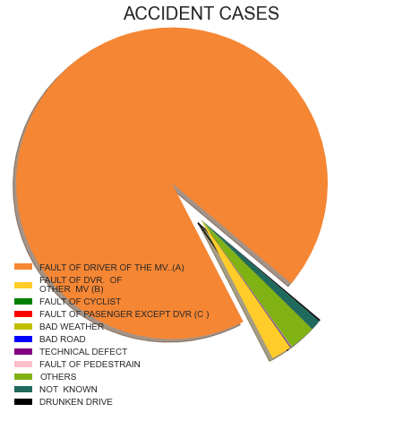

```python
typecases=tgroup.loc['CASES']
y=typecases
c=['#F58634','#FFCC29','green','red','y','blue','purple','pink','#81B214','#206A5D','black']
plt.figure(figsize=(12,8))
plt.pie(typecases.sum(),startangle=320,shadow=True,colors=c,explode=(0.3,0,0,0,0,0,0,0,0,0,0))
plt.legend(labels=typecases.columns,loc="lower left")
plt.title("ACCIDENT CASES",fontsize=20)
plt.show()
```

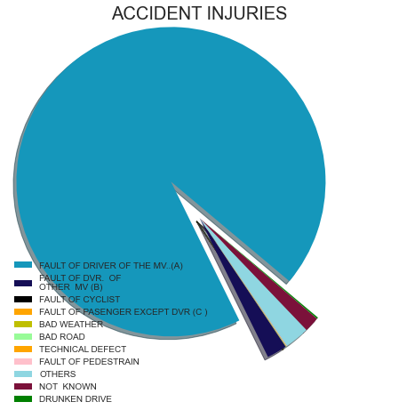

```python
type_injuries=tgroup.loc['INJURY']
c=['#1597BB','#150E56','black','orange','y','palegreen','orange','pink','#8FD6E1','#7B113A','g']
plt.figure(figsize=(12,8))
plt.pie(type_injuries.sum(),startangle=320,shadow=True,colors=c,explode=(0.3,0,0,0,0,0,0,0,0,0,0))
plt.legend(labels=typecases.columns,loc="lower left",title="")
plt.title("ACCIDENT INJURIES",fontsize=20)
plt.show()
```

[figure not shown]

```python
type_death=tgroup.loc['DEATH']
c=['#F55C47','#9FE6A0','green','orange','y','blue','orange','pink','#4AA96C','#564A4A','black']
plt.figure(figsize=(12,8))
plt.pie(typecases.sum(),startangle=320,shadow=True,colors=c,explode=(0.3,0,0,0,0,0,0,0,0,0,0))
plt.legend(labels=typecases.columns,loc="lower left",title="")
plt.title("ACCIDENT DEATHS",fontsize=20)
plt.show()
```

# CONCLUSION

When analyse the data based on time intervals and type of roads which accident occured, data showing that most number of accident cases registered and most number of accident injuries in the time interval of 3.00PM to 6.00PM, and most number of accident deaths occured in the time interval of 6.00PM to 9.00PM. Most number of accident cases ,injuries and deaths were on the roads which are other than National highway and State high ways in Kerala.